# On the nature of the BOLD fMRI contrast mechanism - ScienceDirect

- View **PDF**

## [Magnetic Resonance Imaging](https://www.sciencedirect.com/journal/magnetic-resonance-imaging)

[Volume 22, Issue 10](https://www.sciencedirect.com/journal/magnetic-resonance-imaging/vol/22/issue/10), December 2004, Pages 1517-1531

# Review article On the nature of the BOLD fMRI contrast mechanism

https://doi.org/10.1016/j.mri.2004.10.018[Get rights and content](https://s100.copyright.com/AppDispatchServlet?publisherName=ELS&contentID=S0730725X04003017&orderBeanReset=true)

Abstract

Since its development about 15 years ago, functional magnetic resonance imaging (fMRI) has become the leading research tool for mapping brain activity. The technique works by detecting the levels of oxygen in the blood, point by point, throughout the brain. In other words, it relies on a surrogate signal, resulting from changes in oxygenation, blood volume and flow, and does not directly measure neural activity. Although a relationship between changes in brain activity and blood flow has long been speculated, indirectly examined and suggested and surely anticipated and expected, the neural basis of the fMRI signal was only recently demonstrated directly in experiments using combined imaging and intracortical recordings. In the present paper, we discuss the results obtained from such combined experiments. We also discuss our current knowledge of the extracellularly measured signals of the neural processes that they represent and of the structural and functional neurovascular coupling, which links such processes with the hemodynamic changes that offer the surrogate signal that we use to map brain activity. We conclude by considering applications of invasive MRI, including injections of paramagnetic tracers for the study of connectivity in the living animal and simultaneous imaging and electrical microstimulation.

- [**Previous** article in issue](https://www.sciencedirect.com/science/article/pii/S0730725X04003030)
- [**Next** article in issue](https://www.sciencedirect.com/science/article/pii/S0730725X04003054)

## Keywords

Functional magnetic resonance imaging

Monkey brain

Local field potentials

Multiple-unit activity

Synaptic activity

## 1. Introduction

Our view of brain function has improved impressively in recent years as a result of intense efforts to understand the neural mechanisms underlying perception in humans and nonhuman primates. A large body of evidence regarding the processes through which sensory information at the biochemical, electrophysiological and systems levels contributes to the conscious experience of a stimulus has accrued. Our efforts to understand the organization and function of the sensory and perceptual systems have been greatly aided by the development of new techniques including novel and powerful methods of molecular biology, the refinement of recordings from single and multiple cells for short or long periods and noninvasive neuroimaging techniques allowing us to localize and study activity within the human brain while subjects perform a variety of cognitive tasks.

The contribution of neuroimaging cannot possibly be overemphasized. All our mental capacities, ranging from sensory representation and perception to reasoning and planning, rely on distributed, synergistic activities of large neural populations; therefore, understanding these not only requires a comprehension of the physiological workings of individual neurons and glia cells but also demands a detailed map of the brain's functional architecture, a description of the connections between populations of neurons and insights into the operations performed by the neural networks involved in the task at hand.

The present review deals with spatiotemporally resolved functional magnetic resonance imaging (fMRI) in monkeys and its combination with other invasive neuroscientific techniques. Emphasis will be placed on simultaneous imaging and electrophysiology experiments aiming to elucidate the neural basis of the blood oxygen level-dependent (BOLD) signal. We first review the basic organizational principles of the cortical system. Although many examples are drawn from the visual system, generality is hardly sacrificed as evidence over the last decades suggest a similar organization in any other sensory system studied. Our intention is not to provide the reader with an exhaustive review on sensory or perceptual processing; instead, we summarize examples of current work showing the increasing need of neuroimaging and integrative approaches in addressing many of the interesting questions raised by systems neuroscience. A brief discussion on the principles of energy metabolism and neurovascular coupling follows, subsequent to which the neural and BOLD signals are examined in some detail.

### 1.1. Maps and modular organization

Sensory systems are characterized by topographical organization in the sense that receptors in the peripheral receptive sheet project to central neurons in an orderly manner preserving neighborhood relationships. Within each modality, there are multiple such maps representing the sensory surface. Examples of maps (considering columns as spatial units) are the primary cortical areas of the visual, auditory and somatosensory modalities. Topographical maps, among others, imply local processing. In the case of the visual system, images from the retina at the back of each eye are channeled first to a subdivision of the cerebral hemispheres deep in the brain called the lateral geniculate nucleus (LGN) and, from then on, to the primary visual cortex. In the primary visual cortex (V1), neurons were thought to analyze *local* spatial information within their small receptive fields (RF), basically ignoring processing carried out elsewhere.

It is notable that in the past few years this concept was radically modified by studies showing that V1 cells can actually integrate information over a much larger part of visual space than originally believed and may be an important part of the network underlying perceptual organization. Because their responses are not solely determined by the optimal stimulus with their classical RF [1], they can rather be considerably modulated by perceived brightness, perceptual “pop-out” or grouping of line segments, figure-ground segregation based on a variety of visual cues [2], [3], [4] and the attentional requirement of the task (for a review, see Ref. [5]).

What was previously thought of as a static RF with fixed physiological properties is now conceived as a context-dependent dynamic entity that may undergo shifts in preferred orientation [6], position or size [7] or may modulate activity as a function of viewing distance [8]. Modulation of contextual effects, possibly through the feedback connections, may also be the mechanism by which attention affects the response of V1 cells [9]. Many of these effects are, at least in part, attributable to horizontal or feedback connections. Disentangling the relative contributions of feedforward, lateral and feedback connections is of obvious importance for understanding both sensory and perceptual processing and is likely to instigate a great deal of future research; it is also likely to require an increasingly greater involvement of neuroimaging in a typical neuroscience laboratory.

The influence of context on cell responsiveness is one prominent example of dynamic neural behavior; plasticity of maps, another. Neurons in various cortical sensory areas, even in the earliest ones, are far more flexible and mutable in their functional properties than previously thought. Maps are not fixed but are instead continuously modified by experience [10], [11] and are likely involved in perceptual learning [10], [11], [12].

Finally, modular organization is a principle shared by most sensory systems. In the visual system, modularity was already well established in the 1970s with the discovery of multiple areas that are functionally specialized to undertake different tasks and have certain hierarchical relationships with each other (for a review, see Refs. [13], [14]). From a physiological viewpoint, the notion of hierarchical organization emerged from the pioneering experiments of David Hubel and Torsten Wiesel on the structure of RFs in visual cortex. Evidence from anatomy came through the observation that different types of corticocortical connections [15], initially called *rostral* and *caudal* and subsequently termed feedforward and feedback, can be distinguished by their neurons of origin as well as by the highly specific laminar distribution of their efferent terminal arborizations.

Further detailed physiological and anatomical studies yielded an elaborate route map describing the functional organization of the visual system [16], [17]. In addition, an influential proposal that two anatomically distinct and functionally specialized cortical streams of visual processing emanating from the primary visual cortex exist — a dorsal, *occipitoparietal* stream stretching through the visual association areas of the parietal lobe, which processes spatial information, and a ventral, *occipitotemporal* stream through the visual areas of the temporal lobe, which is involved in the representation of visual objects — was made based on anatomical, physiological and lesion studies [18], [19].

Recently, a series of long-awaited tract-tracing, electrophysiological and lesion experiments in monkeys as well as imaging experiments in humans revealed a similar hierarchical organization in the primate auditory system (see, for a review, Ref. [20]). The reported similarity in the organization of the visual and auditory systems is in good agreement with the parallel nature of the visual and auditory perceptual requirements; namely, the localization and identification of patterns. While the former system integrates information across space and time, the latter does so over frequency and time dimensions.

### 1.2. Neurons, networks and perception

Perceptual organization, selective or attentive information processing, decision making and categorization are only a few of the cognitive capacities intensively investigated in today's neuroscience, which seeks to understand the relationship between the mind and the brain. All these capacities rely on distributed, synergistic activities of large neural populations; therefore, understanding these not only requires a comprehension of the physiological workings of individual neurons and glia cells but also demands a detailed map of the brain's functional architecture, a description of the connections between populations of neurons and insights into the operations performed by the neural networks involved in the task at hand.

Yet, until very recently, systems neuroscience almost exclusively has been relying on physiological studies utilizing the much celebrated single microelectrode technique, reporting the number of action potentials produced by an isolated neuron within a unit of time. Although it proved very useful in characterizing the response properties of different structures, the method clearly falls short of providing information on spatiotemporal cooperativeness and on the global, associational operations performed by neural networks.

Understanding perception or cognition will ultimately depend on the development and application of integrative approaches. Single cell recordings, large electrode or tetrode-array recordings, monitoring of action potentials and slow waves must be employed in combination with neuroimaging using calibrated BOLD signals, cerebral blood flow (CBF), volume (CBV) and MR spectroscopy (MRS) of cerebral metabolites and neurotransmitters to obtain the information required for studying the brain's capacity to generate various behaviors. The recent development of high-field MRI and functional CBF imaging as well as MR spectroscopic imaging [chemical shift imaging (CSI)] in our laboratory [see papers in this volume by Pfeuffer et al. [21], [22] (MRI and MRS at 7 T) and Juchem et al. [23] (CSI at 7 T)] directly reflects our conviction that such integrative approaches can and must be applied in systems neuroscience.

Integrative approaches, however, require the interdisciplinary education of researchers and a thorough understanding of, at least, the basics of closely associated research fields. Invasive neuroimaging in a typical neuroscience laboratory, for instance, requires acquaintance — to a certain extent — with the organization of the brain's metabolism and vascular system in addition to fathoming into the workings of the nerve and glia cells. The next paragraphs attempt to briefly review the essentials of these fields, introducing the commonly measured neural signals and continuing with the very basics of metabolism and hemodynamics, to tap the issue of structural and functional neurovascular coupling.

## 2. The neural signals

### 2.1. The compound neural signal

The signal measured by an electrode placed at a neural site represents the mean extracellular field potential (mEFP) from the weighted sum of all sinks and sources along multiple cells (Fig. 1). If a microelectrode with a small tip is placed close to the soma or axon of a neuron, then the measured mEFP directly reports the spike traffic of that neuron and frequently that of its immediate neighbors as well. Recent studies in rats, for instance, show that tetrodes placed close (within 50 μm) to pyramidal neurons in the hippocampus provide accurate information on a number of their parameters such as latency, amplitude and shape of action potentials because they are simultaneously measured by intracellular recordings [24], [25].

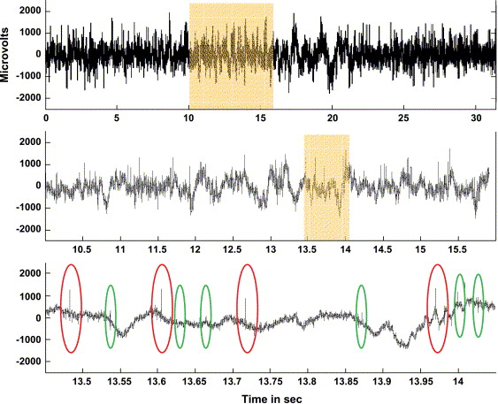

1. [Download : Download full-size image](https://ars.els-cdn.com/content/image/1-s2.0-S0730725X04003017-gr1.jpg)

Fig. 1. Top, A trace from extracellular recordings. The signal represents the changes in the mEFP generated by the sum of current sinks and sources in the volume conductor. It consists of time-varying spatial distributions of action potentials that are riding slower waves generated by population postsynaptic potentials, voltage-gated membrane oscillations, dendritic spikes and afterpotentials. Middle, The shaded region of the top trace expanded to partially reveal the actual spikes and demonstrate better the low-frequency signal changes originating from perisynaptic activity. Bottom, The shaded region of the middle trace is further expanded to reveal the large spikes (red ellipses) originating from projection neurons and the smaller spikes (green ellipses) presumably reflecting interneuron activity. The slow-changing baseline can be further analyzed using time-dependent power-spectrum analysis.

The firing rate of such well-isolated neurons has been the critical measure for comparing neural activity with sensory processing or behavior ever since the early development of microelectrodes. A great deal has been learned since then, and the single-electrode single-unit recording technique still remains the method of choice in many behavioral experiments with conscious animals. However, it also has the drawback of providing information mainly on single RFs, with no access to subthreshold integrative processes or to the associational operations taking place at a given site. Moreover, it suffers from an element of bias toward certain cell types (cf. Ref. [26]) and sizes [27]. The size bias, which is partially responsible for the cell-type bias as well, is considerable. For equivalent transmembrane action potentials, the discharge of a large neuron generates a substantially greater flow of membrane current and a larger extracellular spike than a small cell, and the resulting extracellular field remains above recording noise levels over a greater distance. Larger neurons (cells with 20–30 μm of diameter or greater) are estimated to generate a potential of 100 μV or more within a 100-μm-diameter sphere with the electrode tip at its center [28]. The amplitude of this potential decreases rapidly with increasing distance from the electrode tip because of the aforementioned low-pass properties of the extracellular medium.

For distances larger than ca. 140 μm, spikes become indistinguishable from background noise [25]. Spikes generated by large neurons will thus remain above the noise level over a greater distance from the cell than spikes from small neurons, so microelectrodes are likely to sample their somas or axons preferentially, a prediction supported by experimental work [27], [29]. It follows that the commonly measured spikes, especially those reported in alert trained animals, most likely represent only very small neural populations of large cells, which in the cortex are by and large the principal cells (e.g., pyramidal cells in the cerebral cortex and Purkinje neurons in the cerebellar cortex).

If the impedance of the microelectrode is sufficiently low and its exposed tip is a bit farther from the spike-generating sources so that action potentials do not predominate the neural signal, then the electrode can monitor the totality of the potentials in that region. The EFPs recorded under these conditions (see the seminal studies of Refs. [30], [31] are related both to integrative processes (dendritic events) and to spikes generated by several hundreds of neurons. This kind of comprehensive signal (Fig. 2A) can be analyzed in different ways to obtain information originating from different cellular subdivisions and processes. When time resolution is not a limiting factor, the signal can be analyzed with time-dependent frequency analysis (spectrograms with a Hamming window of a few hundreds of milliseconds; Fig. 2B). Each frequency band can then be examined for stimulus-related activity. Alternatively, the signal can be separated in band by using conventional band-pass filtering. A high-pass filter cutoff of approximately 400 Hz is used in most recordings to obtain a signal, which has been shown to reflect multiple-unit spiking activity (MUA); a low-pass filter cutoff of ca. 300 Hz, to obtain the so-called local field potentials (LFPs), which reflect perisynaptic events. A large number of experiments have presented data indicating that such a band separation does indeed underlie different neural events.

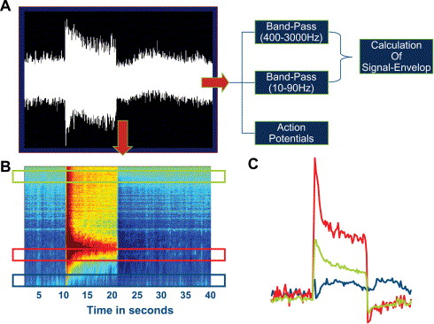

1. [Download : Download full-size image](https://ars.els-cdn.com/content/image/1-s2.0-S0730725X04003017-gr2.jpg)

Fig. 2. Time-dependent frequency analysis of the comprehensive neural signal. (A) The neural signal, recorded during neuroimaging experiments, after removing the gradient interference. (B) Spectrogram of the first 40 s of the neural response. Each time course is expressed in units of the S.D. of the prestimulus period. Color coding indicates the reliability of signal change for each frequency. Red, green and blue lines show three frequency bands, the averages of which are respectively illustrated with the red, green and blue time courses at the bottom right. (C) An alternative to the typical spectrogram that suffers from reduced temporal resolution is band separation through band-pass filtering. Traditionally, two bands are examined in more detail: LFP in the range of 10–90 Hz, including slower waves and gamma activity, and multiple unit activity (400–3000 Hz) representing spiking of large pyramidal cells and some inhibitory interneurons. The band-pass signals can be rectified and low-pass filtered to obtain the “envelop” of the signal or they can be Hilbert transformed to obtain the exact “modulating” function.

### 2.2. Multiple-unit spiking activity

The magnitude of EFPs in the MUA range was shown to be a function of cell and axon sizes. Combined physiology and histology experiments demonstrated that the magnitude of MUA is site- [32] and, thus, cell size-specific [33], varying considerably from one brain region to another but remaining relatively constant for any particular site (e.g., neocortex vs. hippocampus). Homogeneous populations of large cells were found to systematically occur at sites of large-amplitude fast activity and vice versa [34]. Similarly, the magnitude of axonal spikes is directly correlated with the size of the transmitting axon [35], [36]. All of these experiments show that MUA-range activity reflects the variations in the magnitude of extracellular spike potentials. In other words, large-amplitude signal variations in the MUA range reflect large-amplitude extracellular potentials and small-amplitude fast activities are correlated with small ones.

The summation range for the fast MUA has also been studied by a number of investigators. Electrodes with exposed tips of approximately 100 μm (impedance, 40–120 kΩ), for example, were estimated to record from a sphere with a radius of 50–350 μm [34], [37], [38], whereby the activity from each point within the sphere is weighted by a factor depending on the distance of the point from the tip of the electrode [39]. All in all, depending on the recording site and the electrode properties, the MUA most likely represents a weighted sum of the extracellular action potentials of all neurons within a sphere of approximately 140–300 μm radius, with the electrode at its center. Spikes produced by the synchronous firings of many cells can, in principle, be enhanced by summation and thus detected over a larger distance [40], [41].

### 2.3. Local field potentials

The low-frequency range of the mEFP signal, the LFPs, represents mostly slow events reflecting cooperative activity in neural populations. Until recently, these signals were thought to represent exclusively synaptic events. Evidence for this came from combined electroencephalographic [electroencephalography (EEG)] and intracortical recordings showing that the slow wave activity in the EEG is largely independent of neuronal spiking [42], [43], [44], [45]. These studies showed that, unlike the multiple-unit activity, the magnitude of the slow field fluctuations is not correlated with cell size but instead reflects the extent and geometry of dendrites in each recording site. Cells in the so-called open field geometrical arrangement, in which dendrites face one direction and somata another, like the cortical pyramidal cells of cortex, produce strong dendrite-to-soma dipoles when they are activated by synchronous synaptic input.

Evidence concerning the origin of LFPs can also be gathered from current-source density (CSD) analysis and combined field potential and intracellular recordings (for a review of CSD as well as of other types of ensemble recordings, see Refs. [46], [47]. Mitzdorf [48] has suggested that LFPs actually reflect a weighted average of synchronized dendrosomatic components of the synaptic signals of a neural population within 0.5–3 mm of the electrode tip [49]. The upper limits of the spatial extent of LFP summation were indirectly calculated by computing the phase coherence of LFPs as a function of interelectrode distance in experiments with simultaneous multiple-electrode recordings [50].

As mentioned above, LFPs were initially attributed exclusively to population excitatory or inhibitory postsynaptic potentials that are considerably slower than the spiking activity. Later studies, however, provided evidence of the existence of other types of slow activity unrelated to synaptic events such as voltage-dependent membrane oscillations (e.g., Ref. [51]) and spike afterpotentials. To be more specific, the dendrosomatic spikes in the neurons of the central nervous system are generally followed by afterpotentials, a brief delayed depolarization, afterdepolarization and a longer-lasting afterhyperpolarization, which are thought to play an important role in the control of excitation-to-frequency transduction (e.g., Refs. [52], [53], [54]). Afterpotentials, which were shown to be generated by calcium-activated potassium currents (e.g., Refs. [53], [55], [56], [57], [58]), have a duration in the order of tens of milliseconds and most likely contribute to the generation of the LFP signals, as has been first suggested by Buzsaki [59] and Buzsaki and Gage [60]. In summary, LFPs represent slow waveforms including synaptic potentials, afterpotentials of dendrosomatic spikes and voltage-gated membrane oscillations that reflect the input of a given cortical area as well as its local intracortical processing, including the activity of excitatory and inhibitory interneurons.

## 3. Neural and hemodynamic responses

Functional neuroimaging techniques are divided into two fundamentally different approaches: (a) electromagnetic approaches including EEG and magnetoencephalography, both providing a high temporal resolution but poor spatial information, and (b) hemodynamic–metabolic approaches based on the fact that neuronal activity is coupled to energy metabolism and the subsequent changes in CBF and volume. The functional MRI techniques discussed in this paper rely on hemodynamic–metabolic changes during neural activation and its thorough understanding requires some knowledge of (a) the basics of the brain's energy metabolism, (b) the anatomical neurovascular coupling, (c) the type of neural activity and cells generating it, (d) the link between activity and energy demands and (e) the processes coupling the supply and demand of energy to the brain.

### 3.1. Basics of brain energy metabolism

The brain's demand for substrate requires adequate delivery of oxygen and glucose via elaborate mechanisms regulating CBF. Not surprisingly, these mechanisms are closely coupled with regional neural activity. Experimental evidence for such coupling was provided more than 100 years ago in laboratory animals [61]. The seminal study of Roy and Sherrington [61] was followed by the systematic investigations of Kety and Schmidt [62], who introduced the nitrous oxide technique, a global flow measurement method that initially seemed to disprove the notion of a local coupling of cerebral flow and neural activity [63]. But the regional coupling of metabolic rate and neural activity was soon verified with methods allowing local cerebral flow measurements. Although such methods had been used in conscious laboratory animals since the early 1960s [64], a precise quantitative assessment of the relationship between neural activity and regional blood flow was only possible after the introduction of the deoxyglucose autoradiographic technique that enabled spatially resolved measurements of glucose metabolism in laboratory animals [65]. The results of a large number of experiments with the [<sup>14</sup>C] deoxyglucose method have in fact revealed a clear relationship between local cerebral activation and glucose consumption [66].

### 3.2. Structural neurovascular coupling

The blood supply of several cerebral structures including the cortex and deep grey matter has been studied in great detail. Many studies involve intravascular injections outlining the lumen of the vessels. Complete casts of the cortical vascular network can be obtained by infusing low-viscosity resins into the vasculature and allowing the resin to polymerize. Dissolving away the surrounding tissue with alkali leaves a model of the three-dimensional distribution of vessels in that tissue, which can then be sectioned and studied with scanning electron microscopy. The picture that emerged from these studies is of a vascular network whose density largely correlates with the average activity of any given region.

Interestingly, the spatial correlations reported from a large number of investigators have been mainly between vascular density and the number of synapses rather than of neurons [67], [68], [69], [70], [71], [72]. In a careful and detailed study, Duvernoy et al. [72] demonstrated that, based on its density, the human cortical vascular network can be subdivided into four layers parallel to the surface that overlap in a systematic manner with certain portions of the cytoarchitectonically defined Brodmann laminae [73]. Notably, the first Duvernoy layer, consisting of vessels with orientation approximately parallel to neural fibers, is entirely within the lower part of the molecular layer (Layer I), which in the rodent has the lowest concentration of cell bodies and highest density of synapses [74]. Similarly, in the primate, this layer has the lowest concentration of neurons, the highest concentration of astrocytes and a high density of synapses [75]. Duvernoy's second layer coincides with the Lamina II and the upper portion of Lamina III, while the third layer with the highest vascular density covers the lower portion of Layer III, the granular layer (IV) and the upper part of Layer V. Finally, the vascular layer (VI) corresponds to the remaining deep neuronal layers (see Figure 52 of Ref. [72]). In the same study, vascular density differences were found not only in the tangential but also in the vertical planes, with the latter suggesting a column-like densification of the cortical capillary network that is perpendicular to the surface.

The spatial correlations reported for the human brain were later confirmed in animal studies. Zheng et al. [76] from Duke University observed anatomical neurovascular correlations on the finest scales, such as those represented by the smallest capillaries, in the striate cortex of the squirrel monkey. They demonstrated that high microvessel density—measured as the total length of vessels visible in a given slice—is in close correspondence with areas stained by cytochrome oxidase, an enzyme involved in oxidative metabolism and used for the study of the cortical modular organization [77], [78]. Functional subdivisions such as the blobs of V1 and the stripes of area V2 showed considerable overlap with areas of dense vascularization. Microvessels also reflected laminar and areal boundaries. Lamina I had the lowest vascularization and IVc had the highest vascularization, with a IVc/I ratio of 3.3:1 (averaged across animals). Interestingly, the IVc/I ratio of synaptic density in the striate cortex of macaque is 2.43:1, that of astrocytes is 1.2:1 and that of neurons is 78.8:1. Assuming some similarity in the distribution of neurons, synapses and astrocytes between squirrel monkeys and macaques, the recent data would also support the notion of the vascular density being correlated with perisynaptic elements rather than with the density neuronal somata.

Similar results were obtained in different cortical areas of rodents. For instance, endovascular casts revealed capillary densities resembling the whisker barrel pattern characterizing the somatosensory cortex of rats [79], [80] and the spatial patterns of stimulus-induced activation in the auditory cortex of chinchilla [81]. In the latter study, microscopy of corrosion casts was combined with optical imaging of intrinsic signals [82], [83] to examine the covariation of vascular density and hemodynamic response induced by noise stimuli. Similar to previous studies, overlaps were observed between areas in which intrinsic signals were detected, vascularization and distribution of myogenic valves that are thought to control the blood flow to the capillary networks.

### 3.3. Functional neurovascular coupling

The cerebral metabolic rate (CMR) is commonly expressed in terms of oxygen consumption (CMRO<sub>2</sub>) because glucose metabolism is about 90% aerobic and therefore parallels oxygen consumption [84], [85]. The CMRO<sub>2</sub> is likely to vary with neuronal firing properties, shape and size, whereby large projection neurons, which maintain energy-consuming processes such as ion pumping over a large membrane surface, may have larger energy requirements (for detailed references, see Ref. [86]). Moreover, neurons are not the only elements contributing to the energy metabolism of the brain; glia and vascular endothelial cells do so as well. In fact, research suggests a tightly regulated glucose metabolism in all brain cell types. An interesting case is the glia cell known as astrocyte. The structural and functional characteristics of astrocytes make them ideal bridges between the neuropil and the intraparenchymal capillaries. They are indeed massively connected with both neurons and the brain's vasculature and express receptors and uptake sites with which the neurotransmitters released during synaptic activity can interact.

It has been suggested that for each synaptically released glutamate molecule taken up with two to three Na<sup>+</sup> ions by an astrocyte, one glucose molecule enters the same astrocyte, two ATP molecules are produced through glycolysis and two lactate molecules are released and consumed by neurons to yield 18 ATPs through oxidative phosphorylation. Neuronal signals of some sort can therefore trigger receptor-mediated glycogenolysis in astrocytes in a manner similar to peripheral hormones in their target cells. Such signals can be ions or molecules that transiently accumulate in the extracellular space after neuronal activity and/or in fast neurotransmitters eliciting both hemodynamic and metabolic responses in anticipation of or at least in parallel with the regional activation. Such findings, suggesting that presynaptic activity may be a major consumer of energy, are in agreement with microstimulation experiments in which the increase in glucose utilization is assessed during orthodromic and antidromic stimulation, the former activating both presynaptic and postsynaptic terminals and the latter activating only postsynaptic terminals. Increases were only observed during orthodromic stimulation [87], [88], [89] (for a review, see Ref. [90]).

Others, however, have challenged the notion that presynaptic activity is the major energy consumer in the brain [91]. Based on computations of the number of vesicles released per action potential, the number of postsynaptic receptors activated per vesicle released, the metabolic consequences of activating a single receptor and changing ion fluxes and neurotransmitter recycling, these investigators concluded that the greater part of energy expenditure is attributable to the postsynaptic effects of glutamate (about 34% of the energy in rodents and 74% of that in humans are attributable to excitatory postsynaptic currents).

An interesting alternative was recently proposed, that is, that the hemodynamic responses are probably driven by neurotransmitter-related signaling rather than the direct local energy needs of the brain [92]. There is indeed evidence that blood flow in a number of brain structures including the neocortex, cerebellum and hippocampus may be controlled directly by glutamate and GABA. In the cerebellar cortex, for example, the activation of parallel fibers releases glutamate and leads to the depolarization of Purkinje cells and interneurons. These cells, in turn, release GABA. Notably, the increased blood flow that typically follows the activation of parallel fibers is blocked by inhibitors of non-NMDA glutamate receptors, nitric oxide synthase (NOS) and adenosine receptors [93], while microinjections of glutamate have vascular effects similar to those observed during stimulation of the parallel fibers [94]. In the neocortex and hippocampus, microinjection of neurotransmitters dilates pial arterioles and/or precapillary microvessels — an effect attenuated by inhibitors of NOS [95], [96]. According to these latter findings, CBF may be driven by neurotransmitter-related signaling being correlated with but not triggered by the utilization of energy.

All in all, the results from a large number of experiments together with literature-based estimations of energy budget suggest that brain energy consumption is due to perisynaptic activity, that is, neurotransmitter cycling as well as restoration of gradients, following changes in voltage due to input signals and to changes of intrinsic conductances. As will become evident in the next paragraphs, such great energy-requiring postsynaptic gradient restorations are necessary whether or not the integration over the large dendritic sites leads to the production of a typical Na<sup>+</sup>/K<sup>+</sup> action potential at the axon hillock of the neurons.

## 4. Magnetic resonance imaging of the monkey brain

The application of neuroimaging for both noninvasive and invasive research in a nonhuman primate requires high spatiotemporal resolution and good SNR. Only then can the fMRI signals be compared with signals obtained from optical or electrical recordings. To meet these requirements, dedicated vertical, large-bore monkey MR systems were used at high magnetic field (4,7 T) in combination with extensive optimization of both the hardware (gradient performance, RF coils) and the acquisition (automated shimming, zoomed and inversion-prepared EPI, navigators) (see the work of Logothetis et al. [97] and Pfeuffer et al. [21] in this issue. High magnetic fields are known to increase the signal-to-noise and contrast-to-noise ratios as well as the spatial resolution and specificity for functional imaging and to improve the spectral dispersion and quality for MRS and CSI using 1H, 13C, 17O and other nuclei [98], [99].

### 4.1. Structural imaging

High-resolution anatomical scans of the monkey brain are of paramount importance in precisely determining recording sites, in particular when recordings are attempted from different areas simultaneously. Images of high signal and contrast-to-noise ratios were obtained. Fig. 3 shows a typical anatomical scan obtained with a volume coil. The images were generated with T1-weighted, high-resolution (256×256 or 512×512 matrix; 0.5-mm slice thickness) scans by using the 3D-modified driven equilibrium Fourier transform (MDEFT) [100] pulse sequence, with an echo time of 4 ms, repetition time of 14.9 ms, flip angle of 20°, inversion time (τ) of 800 ms and 8 segments. The 3D-MDEFT is largely insensitive to B1 inhomogeneities that are present at high fields due to dielectric resonances, achieving relatively uniform contrast for different brain regions such as cortex, thalamus and basal ganglia. Fig. 4, shows typical functional data obtained using the BOLD contrast mechanism.

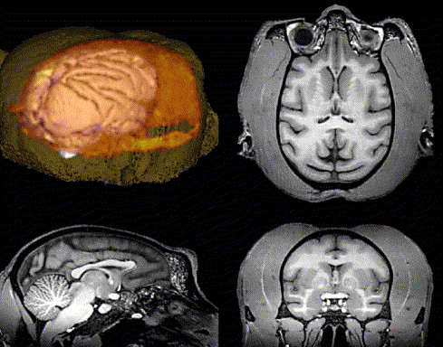

1. [Download : Download full-size image](https://ars.els-cdn.com/content/image/1-s2.0-S0730725X04003017-gr3.jpg)

Fig. 3. High-resolution anatomical scan of the monkey brain. The anatomical images were generated with T1-weighted, high-resolution (256×256 or 512×512 matrix; 0.5-mm thickness) scans by using the 3D-MDEFT.

[figure not shown]

1. [Download : Download full-size image](https://ars.els-cdn.com/content/image/1-s2.0-S0730725X04003017-gr4.jpg)

Fig. 4. Activation of the retinogeniculostriate pathway of the monkey. On the left top, a diagrammatic representation of the visual system is shown. Visual information processing starts in the retina in the back of the eye. The axons of the retinal ganglion cells, forming the optic nerve and tract, project to the thalamic nuclei called the lateral geniculate bodies and then via the optic radiations onto the primary visual cortex, also called the striated cortex or area V1. The left lower panel shows a thresholded *z*-score map rendered on an anatomical 3D-MDEFT T1-weighted scan. The activation was elicited by a polar-transformed checkerboard pattern rotating in alternating directions. The functional resolution in this case was 1 mm<sup>2</sup> in plane with 2-mm slice thickness. Activated are the geniculate bodies and the striate cortex. On the right half, 500-μ slices are shown, demonstrating the specificity of activation in both the thalamus and the cortex. The LGN of the monkey is only about 6 mm across in the rostrocaudal and approximately 5 mm in the dorsoventral and mediolateral directions. The precise anatomical localization of its activation is good evidence for the spatial specificity of fMRI in high magnetic fields.

### 4.2. The BOLD contrast mechanism

For a detailed account of the BOLD mechanism, see Ref. [101]. Here, briefly, the BOLD contrast mechanism was first described in rat studies [102], [103]. BOLD contrast is basically produced by field inhomogeneities induced by deoxyhemoglobin (dHb), which is confined in the intracellular space of the red blood cells that in turn are restricted to the blood vessels. Magnetic susceptibility differences between the dHb-containing compartments and the surrounding space generate magnetic field gradients across and near the compartment boundaries. Pulse sequences designed to be sensitive to such susceptibility differences generate signal alterations whenever the concentration of dHb changes. Upon neural activation, any increase in dHb would be expected to enhance the field inhomogeneities and reduce the BOLD signal. Yet, a few seconds after the onset of stimulation, the BOLD signal actually increases. This enhancement reflects an increase in CBF that overcompensates for the increase in oxygen and ultimately delivers an oversupply of oxygenated blood [104], [105].

The seminal studies of Ogawa et al. excited great interest in applying BOLD fMRI to humans. In 1992, three groups simultaneously and independently obtained results in humans with the BOLD mechanism [106], [107], [108], setting off the flood of fMRI publications that have been appearing in scientific journals ever since. Research over the last decade has established that BOLD contrast depends not only on blood oxygenation but also on CBF and volume, a complex response controlled by several parameters. Despite this complexity, much progress has been made toward quantitatively elucidating various aspects of the BOLD signal and the way it relates to the hemodynamic–metabolic changes occurring in response to elevated neuronal activity (for detailed reading and references, see Refs. [109], [110], [111], [112].

### 4.3. BOLD MRI in monkeys

The left top of Fig. 4 shows a diagrammatic view of the primate visual system to facilitate the interpretation of the functional scans shown in the same figure. The images were obtained with a 4.7-T scanner of 40 cm diameter (see Refs. [113], [114]). Resonators, primate chairs and special transport systems were designed and built to position the anesthetized or alert monkey inside the magnet (e.g., Ref. [115]). The bottom left of Fig. 4 shows the functional results from an anesthetized animal [115]. Thresholded *z*-score maps showing brain activation are color coded and superimposed on anatomical scans. The activation was elicited by a polar-transformed checkerboard pattern rotating in alternating directions. Robust BOLD signals in the LGNs and the striate cortex were routinely obtained. On the right panel of Fig. 4, multiple parasagittal slices are shown cutting through the lateral geniculate body and the striate cortex. Anatomical and functional images of much higher resolution can be obtained with small, tissue-compatible, intraosteally implantable radio frequency coils [97]. Tiny voxel sizes can be obtained with good signal and contrast-to-noise ratios revealing both structural and functional cortical architecture in great detail.

### 4.4. Neural events underlying the BOLD contrast

One way to determine which cellular events contribute to the generation of the hemodynamic response measured in neuroimaging is to examine the correlation of LFPs, MUA and single neuron activity with the hemodynamic response in combined imaging and physiology experiments [116]. At first sight, all these signals seemed to be correlated with the BOLD signal. However, in all experiments, increases in the LFP range were greater in both spectral power and reliability. Furthermore, correlation analysis showed that LFPs are better predictors of the BOLD response than multiple-unit spiking. In fact, it was demonstrated that spike rate is nothing but a “fortuitous” predictor of the BOLD signal, simply because the firing of neurons itself usually happens to correlate with the LFPs.

Important were those cases in which a dissociation between LFP and spiking activity was observed. In all these cases, BOLD was predicted only by the LFPs. In sites exhibiting strong multiple-unit response adaptation, for example, MUA returned to the baseline approximately 2.5 s after stimulus onset, while the activity underlying the LFPs remained elevated for the entire duration of the visual stimulus, being the only neural signal to be associated with the BOLD response.

Similarly, results from ongoing research in our laboratory involving the injection of various neurotransmitters show that selective blocking of MUA has minimal effects on the BOLD responses averaged over regions coextensive with the spread of the injected substance. Finally, a dissociation between spikes and CBF has been also demonstrated in microstimulation studies in the cerebellar cortex [117].

Taken together, these results suggest that changes in the LFPs are more closely related to the evolution of the BOLD signal than changes in the spiking activity of single or multiple neurons. In other words, the BOLD signal mainly reflects the incoming specific or association inputs to an area and the processing of this input information by the local cortical circuitry (including excitatory and inhibitory interneurons). Of course, the incoming subcortical or cortical input to an area will often generate the kind of output activity typically measured in intracortical recordings. In this case, the spike rate will indeed be correlated to the measured BOLD signal. If the activity of large projection neurons, however, is shunted by concurrent modulatory input, the incoming afferent signals and the ongoing intracortical activity will still elicit strong hemodynamic responses. In such cases, spiking activity measured with microelectrodes will be a poor predictor of the BOLD response.

## 5. The study of networks with MRI

### 5.1. Connectivity studies with paramagnetic tracers

Neuroanatomical corticocortical and corticosubcortical connections have been examined mainly by means of degeneration methods and anterograde and retrograde tracer techniques (e.g., Refs. [118], [119]). Although such studies have demonstrated the value of the information gained from the investigation of the topographic connections between different brain areas, they do require fixed, processed tissue for data analysis and therefore cannot be applied to an animal participating in longitudinal studies, where consecutive studies examining an entire circuit could be carried out in the same subjects.

MRI visible tracers that are infused into a specific brain region and are transported anterogradely or retrogradely along the axon may therefore enable us to study connectivity in the living animal. Such paramagnetic tracer studies may also be used to validate and further develop noninvasive fiber-tracking techniques such as diffusion tensor MRI that permit the study of connectivity even in the human brain.

Manganese (Mn<sup>2+</sup>) is an interesting example of an MRI-visible contrast agent. The axonal transport of its radioactive isotope (<sup>54</sup>Mn<sup>2+</sup>) was first studied using histological methods [120], [121]. Although these studies were carried out with the goal of understanding the regional specificity of Mn<sup>2+</sup> distribution, they indicated the usefulness of Mn<sup>2+</sup> as an anterograde neuronal tract tracer. Mn<sup>2+</sup> distribution and transport have been also studied with MRI in rats and mice [122], [123]. Injection of MnCl<sub>2</sub> in the naris or the eye yields a clear signal enhancement in the olfactory and visual pathways [122], [123]. Furthermore, the possibility that the transport of manganese may pass across synapses was suggested by a number of studies [121], [122]. Pautler et al. [122] indicated that Mn<sup>2+</sup> must have traversed a synapse to explain the enhancements detected in the olfactory cortex of the mouse following the injection of its olfactory bulb. In contrast, Watanabe et al. [123] reported that the signal enhancement they observed in their rat study was confined to regions known to receive direct projections from the retina and concluded that it did not constitute evidence for transsynaptic crossing of Mn<sup>2+</sup>.

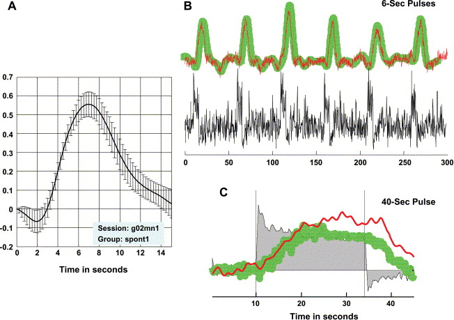

1. [Download : Download full-size image](https://ars.els-cdn.com/content/image/1-s2.0-S0730725X04003017-gr5.jpg)

Fig. 5. Modeling BOLD from neural responses. The next slide shows the application of correlation analysis between neural and hemodynamic signals. The positive lags of the cross-covariance function of the neural and BOLD responses represent the impulse response that is shown in the next slide. (A) Impulse response. Note the initial dip. (B) Neural response, convolution: estimated BOLD response. (C) Note that the system is not time invariant. The impulse response does not predict the response of the system for arbitrary input shifts in time.

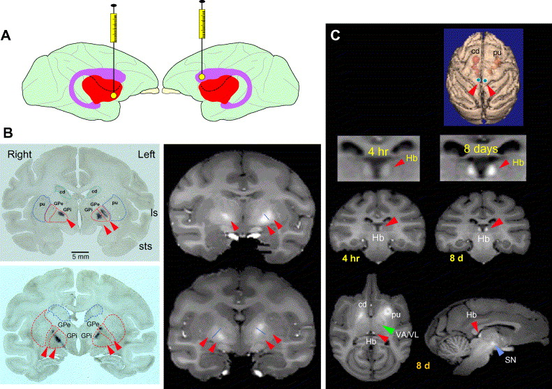

1. [Download : Download full-size image](https://ars.els-cdn.com/content/image/1-s2.0-S0730725X04003017-gr6.jpg)

### 5.2. MR imaging and electrical microstimulation

Our knowledge of connectivity and functional organization could profit a great deal from the combination of MRI with electrical microstimulation. The latter is established as an important neurobiological tool for the study of areal representation and the functional properties of CNS output structures. A new method that combines this technique with fMRI for the detailed study of neural connectivity in the alive animal was recently developed. Specially constructed microelectrodes were used to directly stimulate a selected subcortical or cortical area while simultaneously measuring changes in brain activity, which was indexed by the BOLD signal [125]. The exact location of the stimulation site was determined by means of anatomical scans as well as by the study of the physiological properties of neurons. Electrical stimulation was delivered using a biphasic pulse generator attached to a constant-current stimulus isolation unit. The compensation circuit, designed to minimize interference generated by the switching gradients during recording, was always active, minimizing the gradient-induced currents in the range of the stimulation current. Local microstimulation of striate cortex yielded both local BOLD signals and activation of areas V2, V3 and MT. Microstimulation of dLGN resulted in the activation of both striate cortex and areas V2, V3 and MT. The findings show that microstimulation combined with fMRI can be an exquisite tool for finding and studying target areas of electrophysiological interest.

## 6. Conclusions

The suitability of MRI for functional brain mapping is firmly established. BOLD fMRI has been successfully implemented in awake human subjects as well as in animals such as rats, cats and monkeys. The use of high magnetic fields increases functional signal changes and improves both signal specificity and spatial resolution. MRI studies, in which small voxels of microliter volumes may contain as few as 600–800 cortical neurons, can help us understand how neural networks are organized and how small cell assemblies contribute to the activation patterns revealed in fMRI. The combination of this technique with electrophysiology has fully confirmed the longstanding assumption that the regional activations measured in MR neuroimaging do indeed reflect local increases in neural activity. In addition, it has been demonstrated that fMRI responses mostly reflect the input of a given cortical area and its local intracortical processing, including the activity of excitatory and inhibitory interneurons. Finally, MRI visible tracers and microstimulation appear to be ideal for the study of connectivity in living animals.

## References

**[1]**

J.M. Allman

**Maps in context: some analogies between visual cortical and gentic maps**

L.M. Vaina (Ed.), Matters of intelligence, D. Reidel Publishing Company, Dordrecht (NL) (1987), pp. 369-393

[CrossRef](https://doi.org/10.1007/978-94-009-3833-5_17)[View Record in Scopus](https://www.scopus.com/inward/record.url?eid=2-s2.0-85143019188&partnerID=10&rel=R3.0.0)[Google Scholar](https://scholar.google.com/scholar_lookup?title=Maps%20in%20context%3A%20some%20analogies%20between%20visual%20cortical%20and%20gentic%20maps&publication_year=1987&author=J.M.%20Allman)

**[2]**

J.B. Levitt, J.S. Lund

**Contrast dependence of contextual effects in primate visual cortex**

Nature, 387 (1997), pp. 73-76

[View Record in Scopus](https://www.scopus.com/inward/record.url?eid=2-s2.0-0030994206&partnerID=10&rel=R3.0.0)[Google Scholar](https://scholar.google.com/scholar_lookup?title=Contrast%20dependence%20of%20contextual%20effects%20in%20primate%20visual%20cortex&publication_year=1997&author=J.B.%20Levitt&author=J.S.%20Lund)

**[3]**

K. Zipser, V.A.F. Lamme, P.H. Schiller

**Contextual modulation in primary visual cortex**

J. Neurosci., 16 (22) (1996), pp. 7376-7389

[CrossRef](https://doi.org/10.1523/jneurosci.16-22-07376.1996)[View Record in Scopus](https://www.scopus.com/inward/record.url?eid=2-s2.0-0029851166&partnerID=10&rel=R3.0.0)[Google Scholar](https://scholar.google.com/scholar_lookup?title=Contextual%20modulation%20in%20primary%20visual%20cortex&publication_year=1996&author=K.%20Zipser&author=V.A.F.%20Lamme&author=P.H.%20Schiller)

**[4]**

V.A.F. Lamme

**The neurophysiology of figure-ground segregation in primary visual cortex**

J. Neurosci., 15 (1995), pp. 1605-1615

[CrossRef](https://doi.org/10.1523/jneurosci.15-02-01605.1995)[View Record in Scopus](https://www.scopus.com/inward/record.url?eid=2-s2.0-0028950159&partnerID=10&rel=R3.0.0)[Google Scholar](https://scholar.google.com/scholar_lookup?title=The%20neurophysiology%20of%20figure-ground%20segregation%20in%20primary%20visual%20cortex&publication_year=1995&author=V.A.F.%20Lamme)

**[5]**

V.A. Lamme, H. Super, H. Spekreijse

**Feedforward, horizontal, and feedback processing in the visual cortex**

[83 refs]

Curr. Opin. Neurobiol., 8 (4) (1998), pp. 529-535

[Article](https://www.sciencedirect.com/science/article/pii/S0959438898800421)[Download PDF](https://www.sciencedirect.com/science/article/pii/S0959438898800421/pdf?md5=3463cb743603697504b3a2bd469b07af&pid=1-s2.0-S0959438898800421-main.pdf)[View Record in Scopus](https://www.scopus.com/inward/record.url?eid=2-s2.0-0032144155&partnerID=10&rel=R3.0.0)Google Scholar

**[6]**

D.L. Ringach, M.J. Hawken, R. Shapley

**Dynamics of orientation tuning in macaque primary visual cortex**

Nature, 387 (1997), pp. 281-284

[View Record in Scopus](https://www.scopus.com/inward/record.url?eid=2-s2.0-0030904203&partnerID=10&rel=R3.0.0)Google Scholar

**[7]**

C.D. Gilbert

**Plasticity in visual perception and physiology**

[44 refs]

Curr. Opin. Neurobiol., 6 (2) (1996), pp. 269-274

[Article](https://www.sciencedirect.com/science/article/pii/S0959438896800833)[Download PDF](https://www.sciencedirect.com/science/article/pii/S0959438896800833/pdf?md5=3f5426f7bf87ef99d25dd4d32ead107e&pid=1-s2.0-S0959438896800833-main.pdf)[View Record in Scopus](https://www.scopus.com/inward/record.url?eid=2-s2.0-0029995618&partnerID=10&rel=R3.0.0)[Google Scholar](https://scholar.google.com/scholar_lookup?title=Plasticity%20in%20visual%20perception%20and%20physiology&publication_year=1996&author=C.D.%20Gilbert)

**[8]**

Y. Trotter, S. Celebrini, B. Stricanne, S. Thorpe, M. Imbert

**Modulation of neural stereoscopic processing in primate area V1 by the viewing distance**

Science, 257 (1992), pp. 1279-1281

[CrossRef](https://doi.org/10.1126/science.1519066)[View Record in Scopus](https://www.scopus.com/inward/record.url?eid=2-s2.0-0026806983&partnerID=10&rel=R3.0.0)Google Scholar

**[9]**

M.K. Kapadia, G. Westheimer, C.D. Gilbert

**Dynamics of spatial summation in primary visual cortex of alert monkeys**

Proc. Natl. Acad. Sci. U. S. A., 96 (1999), pp. 12073-12078

[View Record in Scopus](https://www.scopus.com/inward/record.url?eid=2-s2.0-0032693036&partnerID=10&rel=R3.0.0)Google Scholar

**[10]**

G. Gratton

**Attention and probability effects in the human occipital cortex: an optical imaging study**

Neuroreport, 8 (7) (1997), pp. 1749-1753

[View Record in Scopus](https://www.scopus.com/inward/record.url?eid=2-s2.0-0030960692&partnerID=10&rel=R3.0.0)[Google Scholar](https://scholar.google.com/scholar_lookup?title=Attention%20and%20probability%20effects%20in%20the%20human%20occipital%20cortex%3A%20an%20optical%20imaging%20study&publication_year=1997&author=G.%20Gratton)

**[11]**

J. McLean, L.A. Palmer

**Contrast adaptation and excitatory amino acid receptors in cat striate cortex**

Vis. Neurosci., 13 (1996), pp. 1069-1087

[View Record in Scopus](https://www.scopus.com/inward/record.url?eid=2-s2.0-0030278839&partnerID=10&rel=R3.0.0)[Google Scholar](https://scholar.google.com/scholar_lookup?title=Contrast%20adaptation%20and%20excitatory%20amino%20acid%20receptors%20in%20cat%20striate%20cortex&publication_year=1996&author=J.%20McLean&author=L.A.%20Palmer)

**[12]**

M. Carandini, H.B. Barlow, L.P. O'Keefe, A.B. Poirson, J.A. Movshon

**Adaptation to contingencies in macaque primary visual cortex.**

Philos. Trans. R. Soc. Lond., B Biol. Sci., 352 (1358) (1997), pp. 1149-1154

[View Record in Scopus](https://www.scopus.com/inward/record.url?eid=2-s2.0-0031590135&partnerID=10&rel=R3.0.0)Google Scholar

**[13]**

S.M. Zeki

**The functional organization of projections from striate to prestriate visual cortex in the rhesus monkey**

Cold Spring Harb. Symp. Quant. Biol., 40 (1976), pp. 591-600

[CrossRef](https://doi.org/10.1101/SQB.1976.040.01.055)[View Record in Scopus](https://www.scopus.com/inward/record.url?eid=2-s2.0-0016915192&partnerID=10&rel=R3.0.0)Google Scholar

**[14]**

D.C. Van Essen

**Functional organization of primate visual cortex**

A.J. Peters (Ed.), Cerebral cortex, Plenum Publishing, New York (1985), pp. 259-329

[Google Scholar](https://scholar.google.com/scholar_lookup?title=Functional%20organization%20of%20primate%20visual%20cortex&publication_year=1985&author=D.C.%20Van%20Essen)

**[15]**

K.S. Rockland, D.N. Pandya

**Laminar origins and terminations of cortical connections of the occipital lobe in the rhesus monkey**

Brain Res., 179 (1979), pp. 3-20

[Article](https://www.sciencedirect.com/science/article/pii/0006899379904852)[Download PDF](https://www.sciencedirect.com/science/article/pii/0006899379904852/pdf?md5=434393ba5d713c371a64684277441408&pid=1-s2.0-0006899379904852-main.pdf)[View Record in Scopus](https://www.scopus.com/inward/record.url?eid=2-s2.0-0018603117&partnerID=10&rel=R3.0.0)Google Scholar

**[16]**

D. Boussaoud, L.G. Ungerleider, R. Desimone

**Pathways for motion analysis: cortical connections of the medial superior temporal and fundus of the superior temporal visual areas in the macaque**

J. Comp. Neurol., 296 (1990), pp. 462-495

[CrossRef](https://doi.org/10.1002/cne.902960311)[View Record in Scopus](https://www.scopus.com/inward/record.url?eid=2-s2.0-0025282578&partnerID=10&rel=R3.0.0)Google Scholar

**[17]**

D.J. Felleman, D.C. Van Essen

**Distributed hierarchical processing in primate cerebral cortex**

Cereb. Cortex, 1 (1991), pp. 1-47

[CrossRef](https://doi.org/10.1093/cercor/1.1.1)[Google Scholar](https://scholar.google.com/scholar_lookup?title=Distributed%20hierarchical%20processing%20in%20primate%20cerebral%20cortex&publication_year=1991&author=D.J.%20Felleman&author=D.C.%20Van%20Essen)

**[18]**

A. Morel, J. Bullier

**Anatomical segregation of two cortical visual pathways in the macaque monkey**

Vis. Neurosci., 4 (1990), pp. 555-578

[Google Scholar](https://scholar.google.com/scholar_lookup?title=Anatomical%20segregation%20of%20two%20cortical%20visual%20pathways%20in%20the%20macaque%20monkey&publication_year=1990&author=A.%20Morel&author=J.%20Bullier)

**[19]**

L.G. Ungerleider, M. Mishkin

**Two cortical visual systems**

D.J. Ingle (Ed.), Analysis of visual behavior, M.I.T. Press, Cambridge (1982), pp. 549-586

[Google Scholar](https://scholar.google.com/scholar_lookup?title=Two%20cortical%20visual%20systems&publication_year=1982&author=L.G.%20Ungerleider&author=M.%20Mishkin)

**[20]**

J.P. Rauschecker

**Parallel processing in the auditory cortex of primates**

Audiol. Neurootol., 3 (2–3) (1998), pp. 86-103

[View Record in Scopus](https://www.scopus.com/inward/record.url?eid=2-s2.0-0031899045&partnerID=10&rel=R3.0.0)[Google Scholar](https://scholar.google.com/scholar_lookup?title=Parallel%20processing%20in%20the%20auditory%20cortex%20of%20primates&publication_year=1998&author=J.P.%20Rauschecker)

**[21]**

J. Pfeuffer, H. Merkle, M. Beyerlein, T. Steudel, N.K. Logothetis

**Anatomical and functional MR imaging in the macaque monkey using a vertical large-bore 7 Tesla setup**

Magn. Reson. Imaging, 22 (2004), pp. 1343-1359

[Article](https://www.sciencedirect.com/science/article/pii/S0730725X04002942)[Download PDF](https://www.sciencedirect.com/science/article/pii/S0730725X04002942/pdfft?md5=d7920d2c2f60f51ac0601efa9fd84740&pid=1-s2.0-S0730725X04002942-main.pdf)[View Record in Scopus](https://www.scopus.com/inward/record.url?eid=2-s2.0-13544268552&partnerID=10&rel=R3.0.0)Google Scholar

**[22]**

J. Pfeuffer, C. Juchem, H. Merkle, A. Nauerth, N.K. Logothetis

**High-field localized <sup>1</sup>H NMR spectroscopy in the anaesthetized and in the awake monkey**

Magn. Reson. Imaging, 22 (2004), pp. 1361-1372

[Article](https://www.sciencedirect.com/science/article/pii/S0730725X04002954)[Download PDF](https://www.sciencedirect.com/science/article/pii/S0730725X04002954/pdfft?md5=7675e98553e53c98ad557cf4689a6bb8&pid=1-s2.0-S0730725X04002954-main.pdf)[View Record in Scopus](https://www.scopus.com/inward/record.url?eid=2-s2.0-13544258829&partnerID=10&rel=R3.0.0)Google Scholar

**[23]**

C. Juchem, H. Merkle, F. Schick, N.K. Logothetis, J. Pfeuffer

**Region and volume dependencies in spectral linewidth assessed by <sup>1</sup>H 2D MR chemical shift imaging in the monkey brain at 7T**

Magn. Reson. Imaging, 22 (2004), pp. 1373-1383

[Article](https://www.sciencedirect.com/science/article/pii/S0730725X04002966)[Download PDF](https://www.sciencedirect.com/science/article/pii/S0730725X04002966/pdfft?md5=a0f8ba421c0f63c78ed601e745473705&pid=1-s2.0-S0730725X04002966-main.pdf)[View Record in Scopus](https://www.scopus.com/inward/record.url?eid=2-s2.0-13544275776&partnerID=10&rel=R3.0.0)Google Scholar

**[24]**

K.D. Harris, D.A. Henze, J. Csicsvari, H. Hirase, G. Buzsaki

**Accuracy of tetrode spike separation as determined by simultaneous intracellular and extracellular measurements**

J. Neurophysiol., 84 (1) (2000), pp. 401-414

[CrossRef](https://doi.org/10.1152/jn.2000.84.1.401)[View Record in Scopus](https://www.scopus.com/inward/record.url?eid=2-s2.0-0033928411&partnerID=10&rel=R3.0.0)Google Scholar

**[25]**

D.A. Henze, Z. Borhegyi, J. Csicsvari, A. Mamiya, K.D. Harris, G. Buzsaki

**Intracellular features predicted by extracellular recordings in the hippocampus in vivo**

J. Neurophysiol., 84 (1) (2000), pp. 390-400

[CrossRef](https://doi.org/10.1152/jn.2000.84.1.390)[View Record in Scopus](https://www.scopus.com/inward/record.url?eid=2-s2.0-0033930645&partnerID=10&rel=R3.0.0)Google Scholar

**[26]**

J. Stone

**Sampling properties of microelectrodes assessed in the cat's retina**

J. Neurophysiol., 36 (1973), pp. 1071-1079

[CrossRef](https://doi.org/10.1152/jn.1973.36.6.1071)[View Record in Scopus](https://www.scopus.com/inward/record.url?eid=2-s2.0-0015749705&partnerID=10&rel=R3.0.0)[Google Scholar](https://scholar.google.com/scholar?q=Sampling%20properties%20of%20microelectrodes%20assessed%20in%20the%20cats%20retina)

**[27]**

A.L. Towe, G.W. Harding

**Extracellular microelectrode sampling bias**

Exp. Neurol., 29 (2) (1970), pp. 366-381

[Article](https://www.sciencedirect.com/science/article/pii/0014488670900658)[Download PDF](https://www.sciencedirect.com/science/article/pii/0014488670900658/pdf?md5=0c4b3825363388c6feedc50dcaea19bb&pid=1-s2.0-0014488670900658-main.pdf)[View Record in Scopus](https://www.scopus.com/inward/record.url?eid=2-s2.0-0014875118&partnerID=10&rel=R3.0.0)[Google Scholar](https://scholar.google.com/scholar_lookup?title=Extracellular%20microelectrode%20sampling%20bias&publication_year=1970&author=A.L.%20Towe&author=G.W.%20Harding)

**[28]**

W. Rall

**Electrophysiology of a dendritic neuron**

Biophys. J., 2 (1962), pp. 145-167

[Article](https://www.sciencedirect.com/science/article/pii/S0006349562869537)[Download PDF](https://www.sciencedirect.com/science/article/pii/S0006349562869537/pdfft?md5=060f16824766f771f70a54906d538967&pid=1-s2.0-S0006349562869537-main.pdf)[View Record in Scopus](https://www.scopus.com/inward/record.url?eid=2-s2.0-0000599237&partnerID=10&rel=R3.0.0)[Google Scholar](https://scholar.google.com/scholar_lookup?title=Electrophysiology%20of%20a%20dendritic%20neuron&publication_year=1962&author=W.%20Rall)

**[29]**

D.R. Humphrey, W.S. Corrie

**Properties of pyramidal tract neuron system within a functionally defined subregion of primate motor cortex**

J. Neurophysiol., 41 (1) (1978), pp. 216-243

[CrossRef](https://doi.org/10.1152/jn.1978.41.1.216)[View Record in Scopus](https://www.scopus.com/inward/record.url?eid=2-s2.0-0018091396&partnerID=10&rel=R3.0.0)Google Scholar

**[30]**

G.H. Bishop, J.L. O'Leary

**Factors determining the form of the potential record in the vicinity of the synapses of the dorsal nucleus of the lateral geniculate body**

J. Cell. Comp. Physiol., 19 (1942), pp. 315-331

[CrossRef](https://doi.org/10.1002/jcp.1030190307)Google Scholar

**[31]**

R. Lorente de Nó

**Action potentials of the motorneurones of the hypoglossus nucleus**

J. Cell. Comp. Physiol., 29 (1947), pp. 207-288

[CrossRef](https://doi.org/10.1002/jcp.1030290303)[Google Scholar](https://scholar.google.com/scholar_lookup?title=Action%20potentials%20of%20the%20motorneurones%20of%20the%20hypoglossus%20nucleus&publication_year=1947&author=R.%20Lorente%20de%20N%C3%B3)

**[32]**

J.S. Buchwald, F.S. Grover

**Amplitudes of background fast activity characteristic of specific brain sites**

J. Neurophysiol., 33 (1) (1970), pp. 148-159

[CrossRef](https://doi.org/10.1152/jn.1970.33.1.148)[View Record in Scopus](https://www.scopus.com/inward/record.url?eid=2-s2.0-0014712775&partnerID=10&rel=R3.0.0)Google Scholar

**[33]**

P.G. Nelson

**Interaction between spinal motoneurons of the cat**

J. Neurophysiol., 29 (2) (1966), pp. 275-287

[CrossRef](https://doi.org/10.1152/jn.1966.29.2.275)[View Record in Scopus](https://www.scopus.com/inward/record.url?eid=2-s2.0-0013884915&partnerID=10&rel=R3.0.0)[Google Scholar](https://scholar.google.com/scholar_lookup?title=Interaction%20between%20spinal%20motoneurons%20of%20the%20cat&publication_year=1966&author=P.G.%20Nelson)

**[34]**

F.S. Grover, J.S. Buchwald

**Correlation of cell size with amplitude of background fast activity in specific brain nuclei**

J. Neurophysiol., 33 (1) (1970), pp. 160-171

[CrossRef](https://doi.org/10.1152/jn.1970.33.1.160)[View Record in Scopus](https://www.scopus.com/inward/record.url?eid=2-s2.0-0014701204&partnerID=10&rel=R3.0.0)Google Scholar

**[35]**

C. Hunt

**The reflex activity of mammalian small-nerve fibers**

J. Physiol. (Lond.), 115 (1951), pp. 456-469

[CrossRef](https://doi.org/10.1113/jphysiol.1951.sp004681)[View Record in Scopus](https://www.scopus.com/inward/record.url?eid=2-s2.0-0000193249&partnerID=10&rel=R3.0.0)[Google Scholar](https://scholar.google.com/scholar_lookup?title=The%20reflex%20activity%20of%20mammalian%20small-nerve%20fibers&publication_year=1951&author=C.%20Hunt)

**[36]**

H.S. Gasser, H. Grundfest

**Axon diameters in relation to the spike dimensions and the conduction velocity in mammalian A fibers**

Am. J. Physiol., 127 (1939), pp. 393-414

[CrossRef](https://doi.org/10.1152/ajplegacy.1939.127.2.393)[View Record in Scopus](https://www.scopus.com/inward/record.url?eid=2-s2.0-0001420783&partnerID=10&rel=R3.0.0)Google Scholar

**[37]**

A.D. Legatt, J. Arezzo, H.G.J. Vaughan

**Averaged multiple unit activity as an estimate of phasic changes in local neuronal activity: effects of volume-conducted potentials**

J. Neurosci. Methods, 2 (2) (1980), pp. 203-217

[Article](https://www.sciencedirect.com/science/article/pii/0165027080900618)[Download PDF](https://www.sciencedirect.com/science/article/pii/0165027080900618/pdf?md5=96b1d63d1c3af89f1808f9d91693741d&pid=1-s2.0-0165027080900618-main.pdf)[View Record in Scopus](https://www.scopus.com/inward/record.url?eid=2-s2.0-0018852403&partnerID=10&rel=R3.0.0)Google Scholar

**[38]**

C.M. Gray, P.E. Maldonado, M. Wilson, B. McNaughton

**Tetrodes markedly improve the reliability and yield of multiple single-unit isolation from multi-unit recordings in cat striate cortex**

J. Neurosci. Methods, 63 (1995), pp. 43-54

[Article](https://www.sciencedirect.com/science/article/pii/0165027095000852)[Download PDF](https://www.sciencedirect.com/science/article/pii/0165027095000852/pdf?md5=29000559cd0d103312dc423cbc01a5a9&pid=1-s2.0-0165027095000852-main.pdf)[View Record in Scopus](https://www.scopus.com/inward/record.url?eid=2-s2.0-0029623039&partnerID=10&rel=R3.0.0)Google Scholar

**[39]**

C. Nicholson, R. Llinas

**Field potentials in the alligator cerebellum and theory of their relationship to Purkinje cell dendritic spikes**

J. Neurophysiol., 34 (4) (1971), pp. 509-531

[CrossRef](https://doi.org/10.1152/jn.1971.34.4.509)[View Record in Scopus](https://www.scopus.com/inward/record.url?eid=2-s2.0-0015086844&partnerID=10&rel=R3.0.0)Google Scholar

**[40]**

J. Arezzo, A.D. Legatt, H.G.J. Vaughan

**Topography and intracranial sources of somatosensory evoked potentials in the monkey: I. Early components**

Electroencephalogr. Clin. Neurophysiol., 46 (2) (1979), pp. 155-172

[Article](https://www.sciencedirect.com/science/article/pii/0013469479900658)[Download PDF](https://www.sciencedirect.com/science/article/pii/0013469479900658/pdf?md5=735c6d772cb16685816c9baac6b947fe&pid=1-s2.0-0013469479900658-main.pdf)[View Record in Scopus](https://www.scopus.com/inward/record.url?eid=2-s2.0-0018395025&partnerID=10&rel=R3.0.0)Google Scholar

**[41]**

C.M. Huang, J.S. Buchwald

**Interpretation of the vertex short-latency acoustic response: a study of single neurons in the brain stem**

Brain Res., 137 (2) (1977), pp. 291-303

[View Record in Scopus](https://www.scopus.com/inward/record.url?eid=2-s2.0-84986962675&partnerID=10&rel=R3.0.0)Google Scholar

**[42]**

G.H. Fromm, H.W. Bond

**Slow changes in the electrocorticogram and the activity of cortical neurons**

Electroencephalogr. Clin. Neurophysiol., 17 (1964), pp. 520-523

[Article](https://www.sciencedirect.com/science/article/pii/0013469464901828)[Download PDF](https://www.sciencedirect.com/science/article/pii/0013469464901828/pdfft?md5=b8ef9922e7353b57a7f26ebc07225925&pid=1-s2.0-0013469464901828-main.pdf)[View Record in Scopus](https://www.scopus.com/inward/record.url?eid=2-s2.0-0010224037&partnerID=10&rel=R3.0.0)[Google Scholar](https://scholar.google.com/scholar_lookup?title=Slow%20changes%20in%20the%20electrocorticogram%20and%20the%20activity%20of%20cortical%20neurons&publication_year=1964&author=G.H.%20Fromm&author=H.W.%20Bond)

**[43]**

G.H. Fromm, H.W. Bond

**The relationship between neuron activity and cortical steady potentials**

Electroencephalogr. Clin. Neurophysiol., 22 (2) (1967), pp. 159-166

[Article](https://www.sciencedirect.com/science/article/pii/0013469467901563)[Download PDF](https://www.sciencedirect.com/science/article/pii/0013469467901563/pdf?md5=3a4e589728371fb33fb6f943e411046a&pid=1-s2.0-0013469467901563-main.pdf)[View Record in Scopus](https://www.scopus.com/inward/record.url?eid=2-s2.0-0014057573&partnerID=10&rel=R3.0.0)[Google Scholar](https://scholar.google.com/scholar_lookup?title=The%20relationship%20between%20neuron%20activity%20and%20cortical%20steady%20potentials&publication_year=1967&author=G.H.%20Fromm&author=H.W.%20Bond)

**[44]**

C. Ajmone-Marsan

**Electrical activity of the brain: slow waves and neuronal activity**

Isr. J. Med. Sci., 1 (1965), pp. 104-117

[Google Scholar](https://scholar.google.com/scholar_lookup?title=Electrical%20activity%20of%20the%20brain%3A%20slow%20waves%20and%20neuronal%20activity&publication_year=1965&author=C.%20Ajmone-Marsan)

**[45]**

J.S. Buchwald, E.S. Hala, S. Schramm

**A comparison of multi-unit activity and EEG activity recorded from the same brain site in chronic cats during behavioral conditioning**

Nature, 205 (1965), pp. 1012-1014

[CrossRef](https://doi.org/10.1038/2051012a0)[View Record in Scopus](https://www.scopus.com/inward/record.url?eid=2-s2.0-0010274436&partnerID=10&rel=R3.0.0)Google Scholar

**[46]**

U. Mitzdorf

**Current source-density method and application in cat cerebral cortex: investigation of evoked potentials and EEG phenomena**

[324 refs]

Physiol. Rev., 65 (1) (1985), pp. 37-100

[CrossRef](https://doi.org/10.1152/physrev.1985.65.1.37)[View Record in Scopus](https://www.scopus.com/inward/record.url?eid=2-s2.0-0021927140&partnerID=10&rel=R3.0.0)Google Scholar

**[47]**

Z. Nadasdy, J. Csicsvari, M. Penttonen, J. Hetke, K. Wise, G. Buzsaki

**Extracellular recording and analysis of neuronal activity: from single cells to ensembles**

H. Eichenbaum, J.L. Davis (Eds.), Neuronal ensembles: strategies from recording and decoding, Wiley-Liss, New York (1998), pp. 17-55

Google Scholar

**[48]**

U. Mitzdorf

**Properties of the evoked potential generators: current source-density analysis of visually evoked potentials in the cat cortex**

Int. J. Neurosci., 33 (1–2) (1987), pp. 33-59

[CrossRef](https://doi.org/10.3109/00207458708985928)[View Record in Scopus](https://www.scopus.com/inward/record.url?eid=2-s2.0-0023302666&partnerID=10&rel=R3.0.0)Google Scholar

**[49]**

E. Juergens, A. Guettler, R. Eckhorn

**Visual stimulation elicits locked and induced gamma oscillations in monkey intracortical- and EEG-potentials, but not in human EEG**

Exp. Brain Res., 129 (2) (1999), pp. 247-259

[View Record in Scopus](https://www.scopus.com/inward/record.url?eid=2-s2.0-0032717580&partnerID=10&rel=R3.0.0)Google Scholar

**[50]**

E. Juergens, R. Eckhorn, A. Frien, T. Woelbern

**Restricted coupling range of fast oscillations in striate cortex of awake monkey**

N. Elsner, H.-U. Schnitzer (Eds.), Brain and evolution, Thieme, Berlin (1996), p. 418

Google Scholar

**[51]**

A. Kamondi, L. Acsady, G. Buzsaki

**Dendritic spikes are enhanced by cooperative network activity in the intact hippocampus**

J. Neurosci., 18 (10) (1998), pp. 3919-3928

[CrossRef](https://doi.org/10.1523/jneurosci.18-10-03919.1998)[View Record in Scopus](https://www.scopus.com/inward/record.url?eid=2-s2.0-0344269352&partnerID=10&rel=R3.0.0)Google Scholar

**[52]**

R. Granit, D. Kernell, R.S. Smith

**Delayed depolarization and the repetitive response to intracellular stimulation of mammalian motoneurones**

J. Physiol. (Lond.), 168 (1963), pp. 890-910

[CrossRef](https://doi.org/10.1113/jphysiol.1963.sp007229)[View Record in Scopus](https://www.scopus.com/inward/record.url?eid=2-s2.0-0007960005&partnerID=10&rel=R3.0.0)Google Scholar

**[53]**

Y. Harada, T. Takahashi

**The calcium component of the action potential in spinal motoneurones of the rat**

J. Physiol., 335 (1983), pp. 89-100

[CrossRef](https://doi.org/10.1113/jphysiol.1983.sp014521)[View Record in Scopus](https://www.scopus.com/inward/record.url?eid=2-s2.0-0020647597&partnerID=10&rel=R3.0.0)Google Scholar

**[54]**

B. Gustafsson

**Afterpotentials and transduction properties in different types of central neurones**

Arch. Ital. Biol., 122 (1) (1984), pp. 17-30

[Google Scholar](https://scholar.google.com/scholar_lookup?title=Afterpotentials%20and%20transduction%20properties%20in%20different%20types%20of%20central%20neurones&publication_year=1984&author=B.%20Gustafsson)

**[55]**

S.H. Chandler, C.F. Hsaio, T. Inoue, L.J. Goldberg

**Electrophysiological properties of guinea pig trigeminal motoneurons recorded in vitro**

J. Neurophysiol., 71 (1) (1994), pp. 129-145

[CrossRef](https://doi.org/10.1152/jn.1994.71.1.129)[View Record in Scopus](https://www.scopus.com/inward/record.url?eid=2-s2.0-0028158778&partnerID=10&rel=R3.0.0)Google Scholar

**[56]**

K. Walton, B.P. Fulton

**Ionic mechanisms underlying the firing properties of rat neonatal motoneurons studied in vitro**

Neuroscience, 19 (3) (1986), pp. 669-683

[Article](https://www.sciencedirect.com/science/article/pii/0306452286902915)[Download PDF](https://www.sciencedirect.com/science/article/pii/0306452286902915/pdf?md5=59f24c7bdb2827ace8003689672871a8&pid=1-s2.0-0306452286902915-main.pdf)[View Record in Scopus](https://www.scopus.com/inward/record.url?eid=2-s2.0-0022997432&partnerID=10&rel=R3.0.0)Google Scholar

**[57]**

H. Higashi, E. Tanaka, H. Inokuchi, S. Nishi

**Ionic mechanisms underlying the depolarizing and hyperpolarizing afterpotentials of single spike in guinea-pig cingulate cortical neurons**

Neuroscience, 55 (1) (1993), pp. 129-138

[Article](https://www.sciencedirect.com/science/article/pii/030645229390460W)[Download PDF](https://www.sciencedirect.com/science/article/pii/030645229390460W/pdf?md5=6143f6b8bd091ed3fb97f6263fa2ebe8&pid=1-s2.0-030645229390460W-main.pdf)[View Record in Scopus](https://www.scopus.com/inward/record.url?eid=2-s2.0-0027167057&partnerID=10&rel=R3.0.0)Google Scholar

**[58]**

M. Kobayashi, T. Inoue, R. Matsuo, Y. Masuda, O. Hidaka, Y. Kang, *et al.*

**Role of calcium conductances on spike afterpotentials in rat trigeminal motoneurons**

J. Neurophysiol., 77 (6) (1997), pp. 3273-3283

[CrossRef](https://doi.org/10.1152/jn.1997.77.6.3273)[View Record in Scopus](https://www.scopus.com/inward/record.url?eid=2-s2.0-0030845162&partnerID=10&rel=R3.0.0)Google Scholar

**[59]**

G. Buzsaki

**Theta oscillations in the hippocampus**

Neuron, 33 (3) (1931), pp. 325-340

[Google Scholar](https://scholar.google.com/scholar_lookup?title=Theta%20oscillations%20in%20the%20hippocampus&publication_year=1931&author=G.%20Buzsaki)

**[60]**

G. Buzsaki, F.H. Gage

**Mechanisms of action of neural grafts in the limbic system**

[53 refs]

Can. J. Neurol. Sci., 15 (2) (1988), pp. 99-105

[View Record in Scopus](https://www.scopus.com/inward/record.url?eid=2-s2.0-0023905664&partnerID=10&rel=R3.0.0)[Google Scholar](https://scholar.google.com/scholar_lookup?title=Mechanisms%20of%20action%20of%20neural%20grafts%20in%20the%20limbic%20system&publication_year=1988&author=G.%20Buzsaki&author=F.H.%20Gage)

**[61]**

C.S. Roy, C.S. Sherrington

**On the regulation of the blood supply of the brain**

J. Physiol. (Lond.), 11 (1890), pp. 85-108

[View Record in Scopus](https://www.scopus.com/inward/record.url?eid=2-s2.0-0002353719&partnerID=10&rel=R3.0.0)[Google Scholar](https://scholar.google.com/scholar_lookup?title=On%20the%20regulation%20of%20the%20blood%20supply%20of%20the%20brain&publication_year=1890&author=C.S.%20Roy&author=C.S.%20Sherrington)

**[62]**

S.S. Kety, C.F. Schmidt

**Nitrous oxide method for the quantitative determination of cerebral blood flow in man: theory, procedure, and normal values**

J. Clin. Invest., 27 (1948), pp. 475-483

Google Scholar

**[63]**

L. Sokoloff

**The metabolism of the central nervous system in vivo**

J. Field, H.W. Magoun, V.E. Hall (Eds.), Handbook of physiology–neurophysiology, American Physiological Society, Washington (DC) (1960), pp. 1843-1864

[View Record in Scopus](https://www.scopus.com/inward/record.url?eid=2-s2.0-0001256679&partnerID=10&rel=R3.0.0)[Google Scholar](https://scholar.google.com/scholar_lookup?title=The%20metabolism%20of%20the%20central%20nervous%20system%20in%20vivo&publication_year=1960&author=L.%20Sokoloff)

**[64]**

L. Sokoloff

**Relationships among local functional activity, energy metabolism, and blood flow in the central nervous system**

Fed. Proc., 40 (8) (1981), pp. 2311-2316

[View Record in Scopus](https://www.scopus.com/inward/record.url?eid=2-s2.0-0019829662&partnerID=10&rel=R3.0.0)Google Scholar

**[65]**

L. Sokoloff, M. Reivich, C. Kennedy, M.H. DesRosiers, C.S. Patlak, K.D. Pettigrew, *et al.*

**The [C14]deoxyglucose method for the measurement of local cerebral glucose utilization: theory, procedure and normal values in the conscious and anesthetized albino rat**

J. Neurochem., 28 (1977), pp. 897-916

[CrossRef](https://doi.org/10.1111/j.1471-4159.1977.tb10649.x)Google Scholar

**[66]**

L. Sokoloff

**Relation between physiological function and energy metabolism in the central nervous system**

[34 refs]

J. Neurochem., 29 (1) (1977), pp. 13-26

[CrossRef](https://doi.org/10.1111/j.1471-4159.1977.tb03919.x)[View Record in Scopus](https://www.scopus.com/inward/record.url?eid=2-s2.0-0017644156&partnerID=10&rel=R3.0.0)[Google Scholar](https://scholar.google.com/scholar_lookup?title=Relation%20between%20physiological%20function%20and%20energy%20metabolism%20in%20the%20central%20nervous%20system&publication_year=1977&author=L.%20Sokoloff)

**[67]**

H.G. Wolff

**The cerebral blood vessels: anatomical principles**

The circulation of the brain and spinal cord, Williams and Wilkins, Baltimore (1938), pp. 29-67

[View Record in Scopus](https://www.scopus.com/inward/record.url?eid=2-s2.0-13544261430&partnerID=10&rel=R3.0.0)[Google Scholar](https://scholar.google.com/scholar_lookup?title=The%20cerebral%20blood%20vessels%3A%20anatomical%20principles&publication_year=1938&author=H.G.%20Wolff)

**[68]**

R. Lorente de Nó

**Ein Beitrag zur Kenntnis der Gefaessverteilung in der Hirnrinde**

J. Psychol. Neurol., 35 (1928), pp. 19-31

[Google Scholar](https://scholar.google.com/scholar_lookup?title=Ein%20Beitrag%20zur%20Kenntnis%20der%20Gefaessverteilung%20in%20der%20Hirnrinde&publication_year=1928&author=R.%20Lorente%20de%20N%C3%B3)

**[69]**

H.S. Dunning, H.G. Wolff

**The relative vascularity of various parts of the central and peripheral nervous system of the cat and its relation to function**

J. Comp. Neurol., 67 (1937), pp. 433-450

[CrossRef](https://doi.org/10.1002/cne.900670305)[View Record in Scopus](https://www.scopus.com/inward/record.url?eid=2-s2.0-0000295471&partnerID=10&rel=R3.0.0)Google Scholar

**[70]**

E.H. Craigie

**The architecture of the cerebral capillary bed**

Biol. Rev., 20 (1945), pp. 133-146

[View Record in Scopus](https://www.scopus.com/inward/record.url?eid=2-s2.0-0006740768&partnerID=10&rel=R3.0.0)[Google Scholar](https://scholar.google.com/scholar_lookup?title=The%20architecture%20of%20the%20cerebral%20capillary%20bed&publication_year=1945&author=E.H.%20Craigie)

**[71]**

E.H. Craigie

**The vascularity of the cerebral cortex of the albino rat**

J. Comp. Neurol., 33 (1921), pp. 193-212

[CrossRef](https://doi.org/10.1002/cne.900330302)[View Record in Scopus](https://www.scopus.com/inward/record.url?eid=2-s2.0-84980142896&partnerID=10&rel=R3.0.0)[Google Scholar](https://scholar.google.com/scholar_lookup?title=The%20vascularity%20of%20the%20cerebral%20cortex%20of%20the%20albino%20rat&publication_year=1921&author=E.H.%20Craigie)

**[72]**

H.M. Duvernoy, S. Delon, J.L. Vannson

**Cortical blood vessels of the human brain**

Brain Res. Bull., 7 (5) (1981), pp. 519-579

[Article](https://www.sciencedirect.com/science/article/pii/0361923081900071)[Download PDF](https://www.sciencedirect.com/science/article/pii/0361923081900071/pdf?md5=2a5b44a666a57570c005d8d8766f4b29&pid=1-s2.0-0361923081900071-main.pdf)[View Record in Scopus](https://www.scopus.com/inward/record.url?eid=2-s2.0-0019847644&partnerID=10&rel=R3.0.0)[Google Scholar](https://scholar.google.com/scholar_lookup?title=Cortical%20blood%20vessels%20of%20the%20human%20brain&publication_year=1981&author=H.M.%20Duvernoy&author=S.%20Delon&author=J.L.%20Vannson)

**[73]**

K. Brodmann

**Beitrage zur histologischen Lokalisation der Grosshirnride. IIIte Mitteilung: Die Rinderfelder der Niederen Affen**

J. Psychol. Neurol., 4 (1905), pp. 177-226

Google Scholar

**[74]**

A. Schuz, G. Palm

**Density of neurons and synapses in the cerebral cortex of the mouse**

J. Comp. Neurol., 286 (4) (1989), pp. 442-455

[CrossRef](https://doi.org/10.1002/cne.902860404)[View Record in Scopus](https://www.scopus.com/inward/record.url?eid=2-s2.0-0024453643&partnerID=10&rel=R3.0.0)[Google Scholar](https://scholar.google.com/scholar_lookup?title=Density%20of%20neurons%20and%20synapses%20in%20the%20cerebral%20cortex%20of%20the%20mouse&publication_year=1989&author=A.%20Schuz&author=G.%20Palm)

**[75]**

J. O'Kusky, M. Colonnier

**A laminar analysis of the number of neurons, glia, and synapses in the adult cortex (area 17) of adult macaque monkeys**

J. Comp. Neurol., 210 (3) (1982), pp. 278-290

[CrossRef](https://doi.org/10.1002/cne.902100307)[View Record in Scopus](https://www.scopus.com/inward/record.url?eid=2-s2.0-0019990667&partnerID=10&rel=R3.0.0)[Google Scholar](https://scholar.google.com/scholar?q=A%20laminar%20analysis%20of%20the%20number%20of%20neurons,%20glia,%20and%20synapses%20in%20the%20adult%20cortex%20%20of%20adult%20macaque%20monkeys)

**[76]**

D. Zheng, A.-S. LaMantia, D. Purves

**Specialized vascularization of the primate visual cortex**

J. Neurosci., 11 (1991), pp. 2622-2629

[CrossRef](https://doi.org/10.1523/jneurosci.11-08-02622.1991)[View Record in Scopus](https://www.scopus.com/inward/record.url?eid=2-s2.0-0025998232&partnerID=10&rel=R3.0.0)[Google Scholar](https://scholar.google.com/scholar_lookup?title=Specialized%20vascularization%20of%20the%20primate%20visual%20cortex&publication_year=1991&author=D.%20Zheng&author=A.-S.%20LaMantia&author=D.%20Purves)

**[77]**

M.T.T. Wong-Riley

**Changes in the visual system of monocularly sutured or enucleated cats demonstrable with cytochrome oxidase histochemistry**

Brain Res., 171 (1979), pp. 11-28

[Article](https://www.sciencedirect.com/science/article/pii/0006899379907285)[Download PDF](https://www.sciencedirect.com/science/article/pii/0006899379907285/pdf?md5=93eb3758fccd417f66e96b8fb145e876&pid=1-s2.0-0006899379907285-main.pdf)[View Record in Scopus](https://www.scopus.com/inward/record.url?eid=2-s2.0-0018358930&partnerID=10&rel=R3.0.0)Google Scholar

**[78]**

J.C. Horton, D.H. Hubel

**Regular patchy distribution of cytochrome oxidase staining in primary visual cortex of macaque monkey**

Nature, 292 (1981), pp. 762-764

[CrossRef](https://doi.org/10.1038/292762a0)[View Record in Scopus](https://www.scopus.com/inward/record.url?eid=2-s2.0-0019829233&partnerID=10&rel=R3.0.0)Google Scholar

**[79]**

S.B. Cox, T.A. Woolsey, C.M. Rovainen

**Localized dynamic changes in cortical blood flow with whisker stimulation corresponds to matched vascular and neuronal architecture of rat barrels**

J. Cereb. Blood Flow Metab., 13 (6) (1993), pp. 899-913

[CrossRef](https://doi.org/10.1038/jcbfm.1993.113)[View Record in Scopus](https://www.scopus.com/inward/record.url?eid=2-s2.0-0027386163&partnerID=10&rel=R3.0.0)Google Scholar

**[80]**

T.A. Woolsey, C.M. Rovainen, S.B. Cox, M.H. Henegar, G.E. Liang, D. Liu, *et al.*

**Neuronal units linked to microvascular modules in cerebral cortex: response elements for imaging the brain**

[Review, 126 refs]

Cereb. Cortex, 6 (5) (1996), pp. 647-660

[CrossRef](https://doi.org/10.1093/cercor/6.5.647)[View Record in Scopus](https://www.scopus.com/inward/record.url?eid=2-s2.0-0029846966&partnerID=10&rel=R3.0.0)Google Scholar

**[81]**

R.V. Harrison, N. Harel, J. Panesar, R.J. Mount

**Blood capillary distribution correlates with hemodynamic-based functional imaging in cerebral cortex**

Cereb. Cortex, 12 (3) (2002), pp. 225-233

[see comments]

[View Record in Scopus](https://www.scopus.com/inward/record.url?eid=2-s2.0-0036168442&partnerID=10&rel=R3.0.0)Google Scholar

**[82]**

A. Grinvald, E. Lieke, R.D. Frostig, C.D. Gilbert, T.N. Wiesel

**Functional architecture of cortex revealed by optical imaging of intrinsic signals**

Nature, 324 (6095) (1986), pp. 361-364

[CrossRef](https://doi.org/10.1038/324361a0)[View Record in Scopus](https://www.scopus.com/inward/record.url?eid=2-s2.0-0022997296&partnerID=10&rel=R3.0.0)Google Scholar

**[83]**

T. Bonhoeffer, A. Grinvald

**Optical imaging based on intrinsic signals**

A.W. Toga, J.C. Mazziotta (Eds.), Brain mapping, the methods, Academic Press, New York (1996), pp. 55-97

[View Record in Scopus](https://www.scopus.com/inward/record.url?eid=2-s2.0-84911410771&partnerID=10&rel=R3.0.0)[Google Scholar](https://scholar.google.com/scholar_lookup?title=Optical%20imaging%20based%20on%20intrinsic%20signals&publication_year=1996&author=T.%20Bonhoeffer&author=A.%20Grinvald)

**[84]**

BoK Siesjo

**Brain energy metabolism**

John Wiley & Sons, New York (1978)

[Google Scholar](https://scholar.google.com/scholar_lookup?title=Brain%20energy%20metabolism&publication_year=1978&author=BoK%20Siesjo)

**[85]**

A. Ames

**CNS energy metabolism as related to function**

[258 refs]

Brain Res. Brain Res. Rev., 34 (1–2) (2000), pp. 42-68

[Article](https://www.sciencedirect.com/science/article/pii/S0165017300000382)[Download PDF](https://www.sciencedirect.com/science/article/pii/S0165017300000382/pdfft?md5=1fd6260e454418f0de657d51d54dd228&pid=1-s2.0-S0165017300000382-main.pdf)[Google Scholar](https://scholar.google.com/scholar_lookup?title=CNS%20energy%20metabolism%20as%20related%20to%20function&publication_year=2000&author=A.%20Ames)

**[86]**

A. Volterra, P.J. Magistretti, P.G. Haydon

**The tripartite synapse: glia in synaptic transmission**

Oxford University Press, Oxford (NY) (2002)

[Google Scholar](https://scholar.google.com/scholar_lookup?title=The%20tripartite%20synapse%3A%20glia%20in%20synaptic%20transmission&publication_year=2002&author=A.%20Volterra&author=P.J.%20Magistretti&author=P.G.%20Haydon)

**[87]**

M. Kadekaro, A.M. Crane, L. Sokoloff

**Differential effects of electrical stimulation of sciatic nerve on metabolic activity in spinal cord and dorsal root ganglion in the rat**

Proc. Natl. Acad. Sci. U. S. A., 82 (17) (1985), pp. 6010-6013

[CrossRef](https://doi.org/10.1073/pnas.82.17.6010)[View Record in Scopus](https://www.scopus.com/inward/record.url?eid=2-s2.0-1842295295&partnerID=10&rel=R3.0.0)Google Scholar

**[88]**

M. Kadekaro, W.H. Vance, M.L. Terrell, H.J. Gary, H.M. Eisenberg, L. Sokoloff

**Effects of antidromic stimulation of the ventral root on glucose utilization in the ventral horn of the spinal cord in the rat**

Proc. Natl. Acad. Sci. U. S. A., 84 (15) (1987), pp. 5492-5495

[CrossRef](https://doi.org/10.1073/pnas.84.15.5492)[View Record in Scopus](https://www.scopus.com/inward/record.url?eid=2-s2.0-0023387632&partnerID=10&rel=R3.0.0)Google Scholar

**[89]**

R.J. Nudo, R.B. Masterton

**Stimulation-induced [14]C2-deoxyglucose labeling of synaptic activity in the central auditory system**

J. Comp. Neurol., 245 (4) (1986), pp. 553-565

[CrossRef](https://doi.org/10.1002/cne.902450410)[View Record in Scopus](https://www.scopus.com/inward/record.url?eid=2-s2.0-0022560362&partnerID=10&rel=R3.0.0)[Google Scholar](https://scholar.google.com/scholar?q=Stimulation-induced%2014C2-deoxyglucose%20labeling%20of%20synaptic%20activity%20in%20the%20central%20auditory%20system)

**[90]**

M. Jueptner, C. Weiller

**Review: does measurement of regional cerebral blood flow reflect synaptic activity? Implications for PET and fMRI**

[60 refs]

Neuroimage, 2 (1995), pp. 148-156

[Article](https://www.sciencedirect.com/science/article/pii/S1053811985710178)[Download PDF](https://www.sciencedirect.com/science/article/pii/S1053811985710178/pdfft?md5=a86fcee6b2845c33f2f81bc24e90d307&pid=1-s2.0-S1053811985710178-main.pdf)[View Record in Scopus](https://www.scopus.com/inward/record.url?eid=2-s2.0-0028988818&partnerID=10&rel=R3.0.0)[Google Scholar](https://scholar.google.com/scholar?q=Review:%20does%20measurement%20of%20regional%20cerebral%20blood%20flow%20reflect%20synaptic%20activity%20Implications%20for%20PET%20and%20fMRI)

**[91]**

D. Attwell, S.B. Laughlin

**An energy budget for signaling in the grey matter of the brain**

[70 refs]

J. Cereb. Blood Flow Metab., 21 (10) (2001), pp. 1133-1145

[View Record in Scopus](https://www.scopus.com/inward/record.url?eid=2-s2.0-0034784359&partnerID=10&rel=R3.0.0)[Google Scholar](https://scholar.google.com/scholar_lookup?title=An%20energy%20budget%20for%20signaling%20in%20the%20grey%20matter%20of%20the%20brain&publication_year=2001&author=D.%20Attwell&author=S.B.%20Laughlin)

**[92]**

D. Attwell, C. Iadecola

**The neural basis of functional brain imaging signals**

[Review, 66 refs]

Trends Neurosci., 25 (12) (2002), pp. 621-625

[Article](https://www.sciencedirect.com/science/article/pii/S0166223602022646)[Download PDF](https://www.sciencedirect.com/science/article/pii/S0166223602022646/pdfft?md5=0a797e1231da7c27372ee5cb46409fca&pid=1-s2.0-S0166223602022646-main.pdf)[View Record in Scopus](https://www.scopus.com/inward/record.url?eid=2-s2.0-0036889792&partnerID=10&rel=R3.0.0)[Google Scholar](https://scholar.google.com/scholar_lookup?title=The%20neural%20basis%20of%20functional%20brain%20imaging%20signals&publication_year=2002&author=D.%20Attwell&author=C.%20Iadecola)

**[93]**

J. Li, C. Iadecola

**Nitric oxide and adenosine mediate vasodilation during functional activation in cerebellar cortex**

Neuropharmacology, 33 (11) (1994), pp. 1453-1461

[Article](https://www.sciencedirect.com/science/article/pii/0028390894900493)[Download PDF](https://www.sciencedirect.com/science/article/pii/0028390894900493/pdf?md5=61a6c87dd21a4d060f4e64691c609b47&pid=1-s2.0-0028390894900493-main.pdf)[View Record in Scopus](https://www.scopus.com/inward/record.url?eid=2-s2.0-0028019399&partnerID=10&rel=R3.0.0)Google Scholar

**[94]**

G. Yang, C. Iadecola

**Glutamate microinjections in cerebellar cortex reproduce cerebrovascular effects of parallel fiber stimulation**

Am. J. Physiol., 271 (6 Pt. 2) (1996), pp. R1568-R1575

[View Record in Scopus](https://www.scopus.com/inward/record.url?eid=2-s2.0-0030459865&partnerID=10&rel=R3.0.0)Google Scholar

**[95]**

F.M. Faraci, K.R. Breese

**Nitric oxide mediates vasodilatation in response to activation of *N*-methyl-d-aspartate receptors in brain**

Circ. Res., 72 (2) (1993), pp. 476-480

[View Record in Scopus](https://www.scopus.com/inward/record.url?eid=2-s2.0-0027514356&partnerID=10&rel=R3.0.0)Google Scholar

**[96]**

A. Fergus, K.S. Lee

**Regulation of cerebral microvessels by glutamatergic mechanisms**

Brain Res., 754 (1–2) (1997), pp. 35-45

[Article](https://www.sciencedirect.com/science/article/pii/S0006899397000401)[Download PDF](https://www.sciencedirect.com/science/article/pii/S0006899397000401/pdfft?md5=19dac09bb347b5619d09b3b2e71ac4d0&pid=1-s2.0-S0006899397000401-main.pdf)[View Record in Scopus](https://www.scopus.com/inward/record.url?eid=2-s2.0-0030890433&partnerID=10&rel=R3.0.0)[Google Scholar](https://scholar.google.com/scholar_lookup?title=Regulation%20of%20cerebral%20microvessels%20by%20glutamatergic%20mechanisms&publication_year=1997&author=A.%20Fergus&author=K.S.%20Lee)

**[97]**

N.K. Logothetis, H. Merkle, M. Augath, T. Trinath, K. Ugurbil

**Ultra-high resolution fMRI in monkeys with implanted RF coils**

Neuron, 35 (2) (2002), pp. 227-242

[Article](https://www.sciencedirect.com/science/article/pii/S0896627302007754)[Download PDF](https://www.sciencedirect.com/science/article/pii/S0896627302007754/pdfft?md5=c8daeb7107dc9ff8e2242cd5a899eabb&pid=1-s2.0-S0896627302007754-main.pdf)[View Record in Scopus](https://www.scopus.com/inward/record.url?eid=2-s2.0-0037130448&partnerID=10&rel=R3.0.0)Google Scholar

**[98]**

K. Ugurbil, G. Adriany, P. Andersen, W. Chen, R. Gruetter, X.P. Hu, *et al.*

**Magnetic resonance studies of brain function and neurochemistry**

Annu. Rev. Biomed. Eng., 2 (2000), pp. 633-660

[CrossRef](https://doi.org/10.1146/annurev.bioeng.2.1.633)[View Record in Scopus](https://www.scopus.com/inward/record.url?eid=2-s2.0-0039593005&partnerID=10&rel=R3.0.0)Google Scholar

**[99]**

K. Ugurbil, G. Adriany, P. Andersen, W. Chen, M. Garwood, R. Gruetter, *et al.*

**Ultrahigh field magnetic resonance imaging and spectroscopy**

Magn. Reson. Imaging, 21 (10) (2003), pp. 1263-1281

[Article](https://www.sciencedirect.com/science/article/pii/S0730725X03003382)[Download PDF](https://www.sciencedirect.com/science/article/pii/S0730725X03003382/pdfft?md5=9a7828cd8a8466e3c95bfc8d34b33619&pid=1-s2.0-S0730725X03003382-main.pdf)[View Record in Scopus](https://www.scopus.com/inward/record.url?eid=2-s2.0-10744228692&partnerID=10&rel=R3.0.0)Google Scholar

**[100]**

K. Ugurbil, M. Garwood, J. Ellermann, K. Hendrich, R. Hinke, X. Hu, *et al.*

**Imaging at high magnetic fields: initial experiences at 4 T**

Magn. Reson. Q., 9 (4) (1993), pp. 259-277

[View Record in Scopus](https://www.scopus.com/inward/record.url?eid=2-s2.0-0027769152&partnerID=10&rel=R3.0.0)Google Scholar

**[101]**

N.K. Logothetis, B.A. Wandell

**Interpreting the BOLD signal**

[Review]

Annu. Rev. Physiol., 66 (2004), pp. 735-769

[View Record in Scopus](https://www.scopus.com/inward/record.url?eid=2-s2.0-2342586800&partnerID=10&rel=R3.0.0)[Google Scholar](https://scholar.google.com/scholar_lookup?title=Interpreting%20the%20BOLD%20signal&publication_year=2004&author=N.K.%20Logothetis&author=B.A.%20Wandell)

**[102]**

S. Ogawa, T.M. Lee, A.S. Nayak, P. Glynn

**Oxygenation-sensitive contrast in magnetic resonance image of rodent brain at high magnetic fields**

Magn. Reson. Med., 14 (1) (1990), pp. 68-78

[CrossRef](https://doi.org/10.1002/mrm.1910140108)[View Record in Scopus](https://www.scopus.com/inward/record.url?eid=2-s2.0-0025336246&partnerID=10&rel=R3.0.0)Google Scholar

**[103]**

S. Ogawa, T.M. Lee, A.R. Kay, D.W. Tank

**Brain magnetic resonance imaging with contrast dependent on blood oxygenation**

Proc. Natl. Acad. Sci. U. S. A., 87 (24) (1990), pp. 9868-9872

[CrossRef](https://doi.org/10.1073/pnas.87.24.9868)Google Scholar

**[104]**

P.T. Fox, M.E. Raichle

**Focal physiological uncoupling of cerebral blood flow and oxidative metabolism during somatosensory stimulation in human subjects**

Proc. Natl. Acad. Sci. U. S. A., 83 (4) (1986), pp. 1140-1144

[CrossRef](https://doi.org/10.1073/pnas.83.4.1140)[View Record in Scopus](https://www.scopus.com/inward/record.url?eid=2-s2.0-0342963103&partnerID=10&rel=R3.0.0)Google Scholar

**[105]**

P.T. Fox, M.E. Raichle, M.A. Mintun, C. Dence

**Nonoxidative glucose consumption during focal physiologic neural activity**

Science, 241 (4864) (1988), pp. 462-464

[CrossRef](https://doi.org/10.1126/science.3260686)[View Record in Scopus](https://www.scopus.com/inward/record.url?eid=2-s2.0-0023780085&partnerID=10&rel=R3.0.0)Google Scholar

**[106]**

P.A. Bandettini, E.C. Wong, R.S. Hinks, R.S. Tikofsky, J.S. Hyde

**Time course EPI of human brain function during task activation**

Magn. Reson. Med., 25 (2) (1992), pp. 390-397

[CrossRef](https://doi.org/10.1002/mrm.1910250220)[View Record in Scopus](https://www.scopus.com/inward/record.url?eid=2-s2.0-0026871708&partnerID=10&rel=R3.0.0)Google Scholar

**[107]**

K.K. Kwong, J.W. Belliveau, D.A. Chesler, I.E. Goldberg, R.M. Weisskoff, B.P. Poncelet, *et al.*

**Dynamic magnetic resonance imaging of human brain activity during primary sensory stimulation**

Proc. Natl. Acad. Sci. U. S. A., 89 (12) (1992), pp. 5675-5679

[CrossRef](https://doi.org/10.1073/pnas.89.12.5675)[View Record in Scopus](https://www.scopus.com/inward/record.url?eid=2-s2.0-0026653875&partnerID=10&rel=R3.0.0)Google Scholar

**[108]**

S. Ogawa, D.W. Tank, R. Menon, J.M. Ellermann, S.G. Kim, H. Merkle, *et al.*

**Intrinsic signal changes accompanying sensory stimulation: functional brain mapping with magnetic resonance imaging**

Proc. Natl. Acad. Sci. U. S. A., 89 (13) (1992), pp. 5951-5955

[CrossRef](https://doi.org/10.1073/pnas.89.13.5951)[View Record in Scopus](https://www.scopus.com/inward/record.url?eid=2-s2.0-0026754226&partnerID=10&rel=R3.0.0)Google Scholar

**[109]**

C.T. Moonen, P.A. Bandettini, A.L. Baert

**Functional MRI**

Springer Verlag, Berlin (1999)

[Google Scholar](https://scholar.google.com/scholar_lookup?title=Functional%20MRI&publication_year=1999&author=C.T.%20Moonen&author=P.A.%20Bandettini&author=A.L.%20Baert)

**[110]**

Buxton, R. An introduction to functional magnetic resonance imaging: principles and techniques. Cambridge (UK): Cambridge University Press.

[Google Scholar](https://scholar.google.com/scholar?q=Buxton,%20R.%20An%20introduction%20to%20functional%20magnetic%20resonance%20imaging:%20principles%20and%20techniques.%20Cambridge%20:%20Cambridge%20University%20Press.)

**[111]**

P. Jezzard, P.M. Matthews, S.M. Smith

**Functional magnetic resonance imaging: an introduction to methods**

Oxford University Press, Oxford (NY) (2002)

Google Scholar

**[112]**

S.G. Kim, K. Ugurbil

**Comparison of blood oxygenation and cerebral blood flow effects in fMRI: estimation of relative oxygen consumption change**

Magn. Reson. Med., 38 (1) (1997), pp. 59-65

[View Record in Scopus](https://www.scopus.com/inward/record.url?eid=2-s2.0-0030793271&partnerID=10&rel=R3.0.0)Google Scholar

**[113]**

N.K. Logothetis

**On the neural basis of the BOLD fMRI signal**

Philos. Trans. R. Soc. Lond. Biol., 357 (2002), pp. 1003-1037

[View Record in Scopus](https://www.scopus.com/inward/record.url?eid=2-s2.0-0037194549&partnerID=10&rel=R3.0.0)[Google Scholar](https://scholar.google.com/scholar_lookup?title=On%20the%20neural%20basis%20of%20the%20BOLD%20fMRI%20signal&publication_year=2002&author=N.K.%20Logothetis)

**[114]**

N.K. Logothetis

**The underpinnings of the BOLD functional magnetic resonance imaging signal**

[Review]

J. Neurosci., 23 (10) (2003), pp. 3963-3971

[CrossRef](https://doi.org/10.1523/jneurosci.23-10-03963.2003)[View Record in Scopus](https://www.scopus.com/inward/record.url?eid=2-s2.0-0038719640&partnerID=10&rel=R3.0.0)[Google Scholar](https://scholar.google.com/scholar_lookup?title=The%20underpinnings%20of%20the%20BOLD%20functional%20magnetic%20resonance%20imaging%20signal&publication_year=2003&author=N.K.%20Logothetis)

**[115]**

N.K. Logothetis, H. Guggenberger, S. Peled, J. Pauls

**Functional imaging of the monkey brain**

Nat. Neurosci., 2 (6) (1999), pp. 555-562

[View Record in Scopus](https://www.scopus.com/inward/record.url?eid=2-s2.0-0033365133&partnerID=10&rel=R3.0.0)[Google Scholar](https://scholar.google.com/scholar_lookup?title=Functional%20imaging%20of%20the%20monkey%20brain&publication_year=1999&author=N.K.%20Logothetis&author=H.%20Guggenberger&author=S.%20Peled&author=J.%20Pauls)

**[116]**

N.K. Logothetis, J. Pauls, M. Augath, T. Trinath, A. Oeltermann

**Neurophysiological investigation of the basis of the fMRI signal**

Nature, 412 (6843) (2001), pp. 150-157

[View Record in Scopus](https://www.scopus.com/inward/record.url?eid=2-s2.0-0035849892&partnerID=10&rel=R3.0.0)Google Scholar

**[117]**

C. Mathiesen, K. Caesar, N. Akgoren, M. Lauritzen

**Modification of activity-dependent increases of cerebral blood flow by excitatory synaptic activity and spikes in rat cerebellar cortex**

J. Physiol., 512 (Pt. 2) (1998), pp. 555-566

[View Record in Scopus](https://www.scopus.com/inward/record.url?eid=2-s2.0-0032532513&partnerID=10&rel=R3.0.0)Google Scholar

**[118]**

J.A. Saint-Cyr, L.G. Ungerleider, R. Desimone

**Organization of visual cortical inputs to the striatum and subsequent outputs to the pallido-nigral complex in the monkey**

J. Comp. Neurol., 298 (2) (1990), pp. 129-156

[CrossRef](https://doi.org/10.1002/cne.902980202)[View Record in Scopus](https://www.scopus.com/inward/record.url?eid=2-s2.0-0025127876&partnerID=10&rel=R3.0.0)Google Scholar

**[119]**

D.J. Felleman, D.C. Van Essen

**Distributed hierarchical processing in the primate cerebral cortex**

Cereb. Cortex, 1 (1) (1991), pp. 1-47

[CrossRef](https://doi.org/10.1093/cercor/1.1.1)[Google Scholar](https://scholar.google.com/scholar_lookup?title=Distributed%20hierarchical%20processing%20in%20the%20primate%20cerebral%20cortex&publication_year=1991&author=D.J.%20Felleman&author=D.C.%20Van%20Essen)

**[120]**

W.N. Sloot, J.B. Gramsbergen

**Axonal transport of manganese and its relevance to selective neurotoxicity in the rat basal ganglia**

Brain Res., 19 (1–2) (1994), pp. 124-132

[Article](https://www.sciencedirect.com/science/article/pii/0006899394909598)[Download PDF](https://www.sciencedirect.com/science/article/pii/0006899394909598/pdf?md5=34845015f68ddd0607742399b49b23d3&pid=1-s2.0-0006899394909598-main.pdf)[View Record in Scopus](https://www.scopus.com/inward/record.url?eid=2-s2.0-0028142012&partnerID=10&rel=R3.0.0)Google Scholar

**[121]**

A. Takeda, Y. Kodama, S. Ishiwatari, S. Okada

**Manganese transport in the neural circuit of rat CNS**

Brain Res. Bull., 45 (2) (1998), pp. 149-152

[Article](https://www.sciencedirect.com/science/article/pii/S0361923097003304)[Download PDF](https://www.sciencedirect.com/science/article/pii/S0361923097003304/pdfft?md5=c967e950e558434a0933f795c316310d&pid=1-s2.0-S0361923097003304-main.pdf)[View Record in Scopus](https://www.scopus.com/inward/record.url?eid=2-s2.0-0031975292&partnerID=10&rel=R3.0.0)Google Scholar

**[122]**

R.G. Pautler, A.C. Silva, A.P. Koretsky

**In vivo neuronal tract tracing using manganese-enhanced magnetic resonance imaging**

Magn. Reson. Med., 40 (5) (1998), pp. 740-748

[CrossRef](https://doi.org/10.1002/mrm.1910400515)Google Scholar

**[123]**

T. Watanabe, T. Michaelis, J. Frahm

**Mapping of retinal projections in the living rat using high-resolution 3D gradient-echo MRI with Mn<sup>2+</sup>-induced contrast**

Magn. Reson. Med., 46 (3) (2001), pp. 424-429

[View Record in Scopus](https://www.scopus.com/inward/record.url?eid=2-s2.0-0034845549&partnerID=10&rel=R3.0.0)[Google Scholar](https://scholar.google.com/scholar?q=Mapping%20of%20retinal%20projections%20in%20the%20living%20rat%20using%20high-resolution%203D%20gradient-echo%20MRI%20with%20Mn2-induced%20contrast)

**[124]**

K.S. Saleem, J. Pauls, M. Augath, T. Trinath, B.A. Prause, N.K. Logothetis

**Magnetic resonance imaging of neuronal connections in the macaque monkey**

Neuron, 34 (2002), pp. 685-700

[Article](https://www.sciencedirect.com/science/article/pii/S0896627302007183)[Download PDF](https://www.sciencedirect.com/science/article/pii/S0896627302007183/pdfft?md5=4fec1f83a1132c95421477cee82a6eb4&pid=1-s2.0-S0896627302007183-main.pdf)[View Record in Scopus](https://www.scopus.com/inward/record.url?eid=2-s2.0-0037198701&partnerID=10&rel=R3.0.0)Google Scholar

**[125]**

N.K. Logothetis, J. Pauls, A. Oeltermann, M. Augath, T. Trinath

**Studying connectivity with electrical microstimulation & fMRI**

Soc. Neurosci. Abstr., 27 (2001), p. 821

[Google Scholar](https://scholar.google.com/scholar?q=Studying%20connectivity%20with%20electrical%20microstimulation%20%20fMRI)